# Data Wrangling with R

Bibek Sapkota

# Import Data - Basics

task 1:Importing the library

```r
library(readr)
```

## Read Data

task 1:Reading the hsb2.csv data.

```r
read_csv('hsb2.csv')
```

| id | female | race | ses | schtyp | prog | read | write | math | science | socst |
| --- | --- | --- | --- | --- | --- | --- | --- | --- | --- | --- |
| 70 | 0 | 4 | 1 | 1 | 1 | 57 | 52 | 41 | 47 | 57 |
| 121 | 1 | 4 | 2 | 1 | 3 | 68 | 59 | 53 | 63 | 61 |
| 86 | 0 | 4 | 3 | 1 | 1 | 44 | 33 | 54 | 58 | 31 |
| 141 | 0 | 4 | 3 | 1 | 3 | 63 | 44 | 47 | 53 | 56 |
| 172 | 0 | 4 | 2 | 1 | 2 | 47 | 52 | 57 | 53 | 61 |
| 113 | 0 | 4 | 2 | 1 | 2 | 44 | 52 | 51 | 63 | 61 |
| 50 | 0 | 3 | 2 | 1 | 1 | 50 | 59 | 42 | 53 | 61 |
| 11 | 0 | 1 | 2 | 1 | 2 | 34 | 46 | 45 | 39 | 36 |
| 84 | 0 | 4 | 2 | 1 | 1 | 63 | 57 | 54 | 58 | 51 |
| 48 | 0 | 3 | 2 | 1 | 2 | 57 | 55 | 52 | 50 | 51 |

[output cut: 190 more lines]

task 2:specifying the column types.

```r
spec_csv('hsb2.csv')
```

[output not shown]

task 3:Reading the hsb3.csv data.

```r
read_csv('hsb3.csv')
```

| 70 | 0 | 4 | 1...4 | 1...5 | 1...6 | 57...7 | 52 | 41 | 47 | 57...11 |
| --- | --- | --- | --- | --- | --- | --- | --- | --- | --- | --- |
| 121 | 1 | 4 | 2 | 1 | 3 | 68 | 59 | 53 | 63 | 61 |
| 86 | 0 | 4 | 3 | 1 | 1 | 44 | 33 | 54 | 58 | 31 |
| 141 | 0 | 4 | 3 | 1 | 3 | 63 | 44 | 47 | 53 | 56 |
| 172 | 0 | 4 | 2 | 1 | 2 | 47 | 52 | 57 | 53 | 61 |
| 113 | 0 | 4 | 2 | 1 | 2 | 44 | 52 | 51 | 63 | 61 |
| 50 | 0 | 3 | 2 | 1 | 1 | 50 | 59 | 42 | 53 | 61 |
| 11 | 0 | 1 | 2 | 1 | 2 | 34 | 46 | 45 | 39 | 36 |
| 84 | 0 | 4 | 2 | 1 | 1 | 63 | 57 | 54 | 58 | 51 |
| 48 | 0 | 3 | 2 | 1 | 2 | 57 | 55 | 52 | 50 | 51 |
| 75 | 0 | 4 | 2 | 1 | 3 | 60 | 46 | 51 | 53 | 61 |

[output cut: 189 more lines]

task 4:treating the first row of the file as data rather than column names in the resulting dataframe.

```r
read_csv('hsb3.csv', col_names = FALSE)
```

| X1 | X2 | X3 | X4 | X5 | X6 | X7 | X8 | X9 | X10 | X11 |
| --- | --- | --- | --- | --- | --- | --- | --- | --- | --- | --- |
| 70 | 0 | 4 | 1 | 1 | 1 | 57 | 52 | 41 | 47 | 57 |
| 121 | 1 | 4 | 2 | 1 | 3 | 68 | 59 | 53 | 63 | 61 |
| 86 | 0 | 4 | 3 | 1 | 1 | 44 | 33 | 54 | 58 | 31 |
| 141 | 0 | 4 | 3 | 1 | 3 | 63 | 44 | 47 | 53 | 56 |
| 172 | 0 | 4 | 2 | 1 | 2 | 47 | 52 | 57 | 53 | 61 |
| 113 | 0 | 4 | 2 | 1 | 2 | 44 | 52 | 51 | 63 | 61 |
| 50 | 0 | 3 | 2 | 1 | 1 | 50 | 59 | 42 | 53 | 61 |
| 11 | 0 | 1 | 2 | 1 | 2 | 34 | 46 | 45 | 39 | 36 |
| 84 | 0 | 4 | 2 | 1 | 1 | 63 | 57 | 54 | 58 | 51 |
| 48 | 0 | 3 | 2 | 1 | 2 | 57 | 55 | 52 | 50 | 51 |

[output cut: 190 more lines]

task 5:specifying custom column names using the vector cnames for the resulting dataframe columns.

```r
cnames <- c("id", "gender", "race", "socio_economic_status", "school_type", "program", "read", "write", "math", "science", "socst")
read_csv('hsb3.csv', col_names = cnames)
```

| id | gender | race | socio_economic_status | school_type | program | read | write | math | science | socst |
| --- | --- | --- | --- | --- | --- | --- | --- | --- | --- | --- |
| 70 | 0 | 4 | 1 | 1 | 1 | 57 | 52 | 41 | 47 | 57 |
| 121 | 1 | 4 | 2 | 1 | 3 | 68 | 59 | 53 | 63 | 61 |
| 86 | 0 | 4 | 3 | 1 | 1 | 44 | 33 | 54 | 58 | 31 |
| 141 | 0 | 4 | 3 | 1 | 3 | 63 | 44 | 47 | 53 | 56 |
| 172 | 0 | 4 | 2 | 1 | 2 | 47 | 52 | 57 | 53 | 61 |
| 113 | 0 | 4 | 2 | 1 | 2 | 44 | 52 | 51 | 63 | 61 |
| 50 | 0 | 3 | 2 | 1 | 1 | 50 | 59 | 42 | 53 | 61 |
| 11 | 0 | 1 | 2 | 1 | 2 | 34 | 46 | 45 | 39 | 36 |
| 84 | 0 | 4 | 2 | 1 | 1 | 63 | 57 | 54 | 58 | 51 |
| 48 | 0 | 3 | 2 | 1 | 2 | 57 | 55 | 52 | 50 | 51 |

[output cut: 190 more lines]

## Skip Lines

task 1:Reading the data without skipping any lines/rows and observe the result.

```r
read_csv('hsb4.csv')
```

| # A dataset containing demographic information and standardized |
| --- |
| # test scores of high school students. |
| # http://www.ats.ucla.edu/stat/spss/whatstat/whatstat.htm |
| id,female,race,ses,schtyp,prog,read,write,math,science,socst |
| 70,0,4,1,1,1,57,52,41,47,57 |
| 121,1,4,2,1,3,68,59,53,63,61 |
| 86,0,4,3,1,1,44,33,54,58,31 |
| 141,0,4,3,1,3,63,44,47,53,56 |
| 172,0,4,2,1,2,47,52,57,53,61 |
| 113,0,4,2,1,2,44,52,51,63,61 |
| 50,0,3,2,1,1,50,59,42,53,61 |

[output cut: 193 more lines]

task 2:Skiping the first 3 lines as they contain information about the data set which we do not need.

```r
read_csv('hsb4.csv', skip = 3)
```

| id | female | race | ses | schtyp | prog | read | write | math | science | socst |
| --- | --- | --- | --- | --- | --- | --- | --- | --- | --- | --- |
| 70 | 0 | 4 | 1 | 1 | 1 | 57 | 52 | 41 | 47 | 57 |
| 121 | 1 | 4 | 2 | 1 | 3 | 68 | 59 | 53 | 63 | 61 |
| 86 | 0 | 4 | 3 | 1 | 1 | 44 | 33 | 54 | 58 | 31 |
| 141 | 0 | 4 | 3 | 1 | 3 | 63 | 44 | 47 | 53 | 56 |
| 172 | 0 | 4 | 2 | 1 | 2 | 47 | 52 | 57 | 53 | 61 |
| 113 | 0 | 4 | 2 | 1 | 2 | 44 | 52 | 51 | 63 | 61 |
| 50 | 0 | 3 | 2 | 1 | 1 | 50 | 59 | 42 | 53 | 61 |
| 11 | 0 | 1 | 2 | 1 | 2 | 34 | 46 | 45 | 39 | 36 |
| 84 | 0 | 4 | 2 | 1 | 1 | 63 | 57 | 54 | 58 | 51 |
| 48 | 0 | 3 | 2 | 1 | 2 | 57 | 55 | 52 | 50 | 51 |

[output cut: 190 more lines]

## Maximum Lines

task 1:Reading the first 120 rows from the hsb2 dataset.

```r
read_csv('hsb2.csv', n_max = 120)
```

| id | female | race | ses | schtyp | prog | read | write | math | science | socst |
| --- | --- | --- | --- | --- | --- | --- | --- | --- | --- | --- |
| 70 | 0 | 4 | 1 | 1 | 1 | 57 | 52 | 41 | 47 | 57 |
| 121 | 1 | 4 | 2 | 1 | 3 | 68 | 59 | 53 | 63 | 61 |
| 86 | 0 | 4 | 3 | 1 | 1 | 44 | 33 | 54 | 58 | 31 |
| 141 | 0 | 4 | 3 | 1 | 3 | 63 | 44 | 47 | 53 | 56 |
| 172 | 0 | 4 | 2 | 1 | 2 | 47 | 52 | 57 | 53 | 61 |
| 113 | 0 | 4 | 2 | 1 | 2 | 44 | 52 | 51 | 63 | 61 |
| 50 | 0 | 3 | 2 | 1 | 1 | 50 | 59 | 42 | 53 | 61 |
| 11 | 0 | 1 | 2 | 1 | 2 | 34 | 46 | 45 | 39 | 36 |
| 84 | 0 | 4 | 2 | 1 | 1 | 63 | 57 | 54 | 58 | 51 |
| 48 | 0 | 3 | 2 | 1 | 2 | 57 | 55 | 52 | 50 | 51 |

[output cut: 110 more lines]

## Column Types

task 1:Specifying the data types for each column explicitly, where certain columns are defined as integers and others as factor variables with specified levels.

```r
read_csv('hsb2.csv', col_types = list(
  col_integer(), col_factor(levels = c("0", "1")),
  col_factor(levels = c("1", "2", "3", "4")), col_factor(levels = c("1", "2", "3")),
  col_factor(levels = c("1", "2")), col_factor(levels = c("1", "2", "3")),
  col_integer(), col_integer(), col_integer(), col_integer(),
  col_integer())
)
```

| id | female | race | ses | schtyp | prog | read | write | math | science | socst |
| --- | --- | --- | --- | --- | --- | --- | --- | --- | --- | --- |
| 70 | 0 | 4 | 1 | 1 | 1 | 57 | 52 | 41 | 47 | 57 |
| 121 | 1 | 4 | 2 | 1 | 3 | 68 | 59 | 53 | 63 | 61 |
| 86 | 0 | 4 | 3 | 1 | 1 | 44 | 33 | 54 | 58 | 31 |
| 141 | 0 | 4 | 3 | 1 | 3 | 63 | 44 | 47 | 53 | 56 |
| 172 | 0 | 4 | 2 | 1 | 2 | 47 | 52 | 57 | 53 | 61 |
| 113 | 0 | 4 | 2 | 1 | 2 | 44 | 52 | 51 | 63 | 61 |
| 50 | 0 | 3 | 2 | 1 | 1 | 50 | 59 | 42 | 53 | 61 |
| 11 | 0 | 1 | 2 | 1 | 2 | 34 | 46 | 45 | 39 | 36 |
| 84 | 0 | 4 | 2 | 1 | 1 | 63 | 57 | 54 | 58 | 51 |
| 48 | 0 | 3 | 2 | 1 | 2 | 57 | 55 | 52 | 50 | 51 |

[output cut: 190 more lines]

task 2:Secifying column types only for selected columns (id as integer, prog as a factor with specified levels, and read as integer).

```r
read_csv('hsb2.csv', col_types = cols_only(id = col_integer(),
  prog = col_factor(levels = c("1", "2", "3")), read = col_integer())
)
```

| id | prog | read |
| --- | --- | --- |
| 70 | 1 | 57 |
| 121 | 3 | 68 |
| 86 | 1 | 44 |
| 141 | 3 | 63 |
| 172 | 2 | 47 |
| 113 | 2 | 44 |
| 50 | 1 | 50 |
| 11 | 2 | 34 |
| 84 | 1 | 63 |
| 48 | 2 | 57 |

[output cut: 190 more lines]

# Import Data - Advanced

task 1:Reading the library

```r
library(readxl)
library(haven)
```

## List Sheets

task 1:Seeing how many sheets are present in sample.xls file and their respective names using excel_sheets().

```r
excel_sheets('sample.xls')
```

```
[1] "ecom"
```

## Read Sheet

task 1:Reading data from the ecom sheet of the sample.xls file using read_excel(), specifying the sheet number.

```r
read_excel('sample.xls', sheet = 1)
```

| channel | users | new_users | sessions | bounce_rate |
| --- | --- | --- | --- | --- |
| Organic Search | 43296 | 40238 | 50810 | 48.72% |
| Direct | 12916 | 12311 | 16419 | 49.27% |
| Referral | 10983 | 7636 | 18105 | 22.26% |
| Social | 10346 | 10029 | 11101 | 61.92% |
| Display | 5564 | 4790 | 7220 | 83.30% |
| Paid Search | 2687 | 2205 | 3438 | 38.02% |
| Affiliates | 1773 | 1585 | 2167 | 55.75% |

task 2:Specifying the sheet name.

```r
read_excel('sample.xls', sheet = 'ecom')
```

| channel | users | new_users | sessions | bounce_rate |
| --- | --- | --- | --- | --- |
| Organic Search | 43296 | 40238 | 50810 | 48.72% |
| Direct | 12916 | 12311 | 16419 | 49.27% |
| Referral | 10983 | 7636 | 18105 | 22.26% |
| Social | 10346 | 10029 | 11101 | 61.92% |
| Display | 5564 | 4790 | 7220 | 83.30% |
| Paid Search | 2687 | 2205 | 3438 | 38.02% |
| Affiliates | 1773 | 1585 | 2167 | 55.75% |

## Read Specific Cells

task 1:Reading data from first 4 rows of columns B and C, we will specify the range as “B1:C4”

```r
read_excel('sample.xls', sheet = 1, range = "B1:C4")
```

| users | new_users |
| --- | --- |
| 43296 | 40238 |
| 12916 | 12311 |
| 10983 | 7636 |

task 2:Reading data from first 5 rows of columns A, B and C, we will specify the range as “A1:C5”

```r
read_excel('sample.xls', sheet = 1, range = "A1:C5")
```

| channel | users | new_users |
| --- | --- | --- |
| Organic Search | 43296 | 40238 |
| Direct | 12916 | 12311 |
| Referral | 10983 | 7636 |
| Social | 10346 | 10029 |

task 3:Reading the data from first 3 rows and 2 columns starting from A4.

```r
read_excel('sample.xls', sheet = 1, col_names = FALSE,
  range = anchored("A4", dim = c(3, 2)))
```

| ...1 | ...2 |
| --- | --- |
| Referral | 10983 |
| Social | 10346 |
| Display | 5564 |

task 4:Reading data from the first 6 rows and 4 columns.

```r
read_excel('sample.xls', sheet = 1,
  range = cell_limits(c(1, 1), c(6, 4)))
```

| channel | users | new_users | sessions |
| --- | --- | --- | --- |
| Organic Search | 43296 | 40238 | 50810 |
| Direct | 12916 | 12311 | 16419 |
| Referral | 10983 | 7636 | 18105 |
| Social | 10346 | 10029 | 11101 |
| Display | 5564 | 4790 | 7220 |

task 5:Reading data from all the rows from the second column onwards.

```r
read_excel('sample.xls', sheet = 1,
  range = cell_limits(c(1, 2), c(NA, NA)))
```

| users | new_users | sessions | bounce_rate |
| --- | --- | --- | --- |
| 43296 | 40238 | 50810 | 48.72% |
| 12916 | 12311 | 16419 | 49.27% |
| 10983 | 7636 | 18105 | 22.26% |
| 10346 | 10029 | 11101 | 61.92% |
| 5564 | 4790 | 7220 | 83.30% |
| 2687 | 2205 | 3438 | 38.02% |
| 1773 | 1585 | 2167 | 55.75% |

task 6:Reading data from the first 4 rows of columns B and C.(Method 1)

```r
read_excel('sample.xls', sheet = 1,
  range = "B1:C4")
```

| users | new_users |
| --- | --- |
| 43296 | 40238 |
| 12916 | 12311 |
| 10983 | 7636 |

task 7:Reading data from the first 4 rows of columns B and C.(Method 2)

```r
read_excel('sample.xls', sheet = 1,
  range = anchored("B1", dim = c(4, 2)))
```

| users | new_users |
| --- | --- |
| 43296 | 40238 |
| 12916 | 12311 |
| 10983 | 7636 |

task 8:Reading data from the first 4 rows of columns B and C.(Method 3)

```r
read_excel('sample.xls', sheet = 1,
  range = cell_limits(c(1, 2), c(4, 3)))
```

| users | new_users |
| --- | --- |
| 43296 | 40238 |
| 12916 | 12311 |
| 10983 | 7636 |

## Read Specific Rows

task 1:Reading the first 4 rows of data from the sample.xls file.

```r
read_excel('sample.xls', sheet = 1, range = cell_rows(1:4))
```

| channel | users | new_users | sessions | bounce_rate |
| --- | --- | --- | --- | --- |
| Organic Search | 43296 | 40238 | 50810 | 48.72% |
| Direct | 12916 | 12311 | 16419 | 49.27% |
| Referral | 10983 | 7636 | 18105 | 22.26% |

## Read Single Column

task 1:Reading the second column from the sample.xls file using cell_cols().

```r
read_excel('sample.xls', sheet = 1, range = cell_cols(2))
```

| users |
| --- |
| 43296 |
| 12916 |
| 10983 |
| 10346 |
| 5564 |
| 2687 |
| 1773 |

## Read Multiple Columns

```r
read_excel('sample.xls', sheet = 1, range = cell_cols(c(2, 4, 6)))
```

| users | new_users | sessions | bounce_rate | ...5 |
| --- | --- | --- | --- | --- |
| 43296 | 40238 | 50810 | 48.72% | NA |
| 12916 | 12311 | 16419 | 49.27% | NA |
| 10983 | 7636 | 18105 | 22.26% | NA |
| 10346 | 10029 | 11101 | 61.92% | NA |
| 5564 | 4790 | 7220 | 83.30% | NA |
| 2687 | 2205 | 3438 | 38.02% | NA |
| 1773 | 1585 | 2167 | 55.75% | NA |

task 2:Reading data from the 2nd column upto and including the 6th column.

```r
read_excel('sample.xls', sheet = 1, range = cell_cols(c(2:6)))
```

| users | new_users | sessions | bounce_rate | ...5 |
| --- | --- | --- | --- | --- |
| 43296 | 40238 | 50810 | 48.72% | NA |
| 12916 | 12311 | 16419 | 49.27% | NA |
| 10983 | 7636 | 18105 | 22.26% | NA |
| 10346 | 10029 | 11101 | 61.92% | NA |
| 5564 | 4790 | 7220 | 83.30% | NA |
| 2687 | 2205 | 3438 | 38.02% | NA |
| 1773 | 1585 | 2167 | 55.75% | NA |

## Statistical Softwares

task 1:Reading data using read_stata.

```r
read_stata('airline.dta')
```

| year | y | w | r | l | k |
| --- | --- | --- | --- | --- | --- |
| 1948 | 1.214 | 0.243 | 0.1454 | 1.415 | 0.612 |
| 1949 | 1.354 | 0.260 | 0.2181 | 1.384 | 0.559 |
| 1950 | 1.569 | 0.278 | 0.3157 | 1.388 | 0.573 |
| 1951 | 1.948 | 0.297 | 0.3940 | 1.550 | 0.564 |
| 1952 | 2.265 | 0.310 | 0.3559 | 1.802 | 0.574 |
| 1953 | 2.731 | 0.322 | 0.3593 | 1.926 | 0.711 |
| 1954 | 3.025 | 0.335 | 0.4025 | 1.964 | 0.776 |
| 1955 | 3.562 | 0.350 | 0.3961 | 2.116 | 0.827 |
| 1956 | 3.979 | 0.361 | 0.3822 | 2.435 | 0.800 |
| 1957 | 4.420 | 0.379 | 0.3045 | 2.707 | 0.921 |

[output cut: 22 more lines]

task 2:Reading data using read_spss.

```r
read_spss('employee.sav')
```

| id | gender | educ | jobcat | salary | salbegin | jobtime | prevexp | minority |
| --- | --- | --- | --- | --- | --- | --- | --- | --- |
| 1 | m | 15 | 3 | 57000 | 27000 | 98 | 144 | 0 |
| 2 | m | 16 | 1 | 40200 | 18750 | 98 | 36 | 0 |
| 3 | f | 12 | 1 | 21450 | 12000 | 98 | 381 | 0 |
| 4 | f | 8 | 1 | 21900 | 13200 | 98 | 190 | 0 |
| 5 | m | 15 | 1 | 45000 | 21000 | 98 | 138 | 0 |
| 6 | m | 15 | 1 | 32100 | 13500 | 98 | 67 | 0 |
| 7 | m | 15 | 1 | 36000 | 18750 | 98 | 114 | 0 |
| 8 | f | 12 | 1 | 21900 | 9750 | 98 | 0 | 0 |
| 9 | f | 15 | 1 | 27900 | 12750 | 98 | 115 | 0 |
| 10 | f | 12 | 1 | 24000 | 13500 | 98 | 244 | 0 |

[output cut: 464 more lines]

task 3:Reading data using read_sas.

```r
read_sas('airline.sas7bdat')
```

| YEAR | Y | W | R | L | K |
| --- | --- | --- | --- | --- | --- |
| 1948 | 1.214 | 0.243 | 0.1454 | 1.415 | 0.612 |
| 1949 | 1.354 | 0.260 | 0.2181 | 1.384 | 0.559 |
| 1950 | 1.569 | 0.278 | 0.3157 | 1.388 | 0.573 |
| 1951 | 1.948 | 0.297 | 0.3940 | 1.550 | 0.564 |
| 1952 | 2.265 | 0.310 | 0.3559 | 1.802 | 0.574 |
| 1953 | 2.731 | 0.322 | 0.3593 | 1.926 | 0.711 |
| 1954 | 3.025 | 0.335 | 0.4025 | 1.964 | 0.776 |
| 1955 | 3.562 | 0.350 | 0.3961 | 2.116 | 0.827 |
| 1956 | 3.979 | 0.361 | 0.3822 | 2.435 | 0.800 |
| 1957 | 4.420 | 0.379 | 0.3045 | 2.707 | 0.921 |

[output cut: 22 more lines]

# dplyr Basics

task 1:Importing library

```r
library(dplyr)
library(readr)
```

task 2: Reading the data.

```r
ecom <-
  read_csv('https://raw.githubusercontent.com/rsquaredacademy/datasets/master/web.csv',
    col_types = cols_only(device = col_factor(levels = c("laptop", "tablet", "mobile")),
      referrer = col_factor(levels = c("bing", "direct", "social", "yahoo", "google")),
      purchase = col_logical(), n_pages = col_double(), n_visit = col_double(),
      duration = col_double(), order_value = col_double(), order_items = col_double()
    )
  )

ecom
```

| referrer | device | n_visit | n_pages | duration | purchase | order_items | order_value |
| --- | --- | --- | --- | --- | --- | --- | --- |
| google | laptop | 10 | 1 | 693 | FALSE | 0 | 0 |
| yahoo | tablet | 9 | 1 | 459 | FALSE | 0 | 0 |
| direct | laptop | 0 | 1 | 996 | FALSE | 0 | 0 |
| bing | tablet | 3 | 18 | 468 | TRUE | 6 | 434 |
| yahoo | mobile | 9 | 1 | 955 | FALSE | 0 | 0 |
| yahoo | laptop | 5 | 5 | 135 | FALSE | 0 | 0 |
| yahoo | mobile | 10 | 1 | 75 | FALSE | 0 | 0 |
| direct | mobile | 10 | 1 | 908 | FALSE | 0 | 0 |
| bing | mobile | 3 | 19 | 209 | FALSE | 0 | 0 |
| google | mobile | 6 | 1 | 208 | FALSE | 0 | 0 |

[output cut: 990 more lines]

# Average Order Value by Devices

task 1:Calculating the average Order Value by devices.

```r
ecom %>%
  filter(purchase) %>%
  select(device, order_value) %>%
  group_by(device) %>%
  summarise_all(funs(revenue = sum, orders = n())) %>%
  mutate(
    aov = revenue / orders
  ) %>%
  select(device, aov) %>%
  arrange(aov)
```

| device | aov |
| --- | --- |
| tablet | 1425.583 |
| mobile | 1430.667 |
| laptop | 1823.581 |

## Filter Rows

task 1:Filtering the device mobile and Displaying it.

```r
filter(ecom, device == "mobile")
```

| referrer | device | n_visit | n_pages | duration | purchase | order_items | order_value |
| --- | --- | --- | --- | --- | --- | --- | --- |
| yahoo | mobile | 9 | 1 | 955 | FALSE | 0 | 0 |
| yahoo | mobile | 10 | 1 | 75 | FALSE | 0 | 0 |
| direct | mobile | 10 | 1 | 908 | FALSE | 0 | 0 |
| bing | mobile | 3 | 19 | 209 | FALSE | 0 | 0 |
| google | mobile | 6 | 1 | 208 | FALSE | 0 | 0 |
| direct | mobile | 9 | 14 | 406 | TRUE | 3 | 651 |
| yahoo | mobile | 7 | 1 | 19 | FALSE | 7 | 2423 |
| google | mobile | 5 | 1 | 147 | FALSE | 0 | 0 |
| bing | mobile | 0 | 7 | 196 | FALSE | 4 | 237 |
| google | mobile | 10 | 1 | 338 | FALSE | 0 | 0 |

[output cut: 334 more lines]

task 2:Filtering the device mobile and Displaying the purchased one only.

```r
filter(ecom, device == "mobile", purchase)
```

| referrer | device | n_visit | n_pages | duration | purchase | order_items | order_value |
| --- | --- | --- | --- | --- | --- | --- | --- |
| direct | mobile | 9 | 14 | 406 | TRUE | 3 | 651 |
| bing | mobile | 4 | 20 | 440 | TRUE | 3 | 184 |
| bing | mobile | 3 | 18 | 288 | TRUE | 6 | 764 |
| social | mobile | 10 | 11 | 242 | TRUE | 4 | 287 |
| yahoo | mobile | 6 | 14 | 322 | TRUE | 3 | 1443 |
| google | mobile | 1 | 18 | 252 | TRUE | 3 | 2449 |
| social | mobile | 7 | 16 | 352 | TRUE | 10 | 2824 |
| direct | mobile | 4 | 18 | 324 | TRUE | 3 | 1670 |
| social | mobile | 1 | 20 | 520 | TRUE | 5 | 1021 |
| yahoo | mobile | 0 | 13 | 351 | TRUE | 10 | 288 |

[output cut: 26 more lines]

task 3:Filtering the device tablet and N-page which is less than 15.

```r
filter(ecom, device == "tablet", purchase, n_pages < 15)
```

| referrer | device | n_visit | n_pages | duration | purchase | order_items | order_value |
| --- | --- | --- | --- | --- | --- | --- | --- |
| social | tablet | 7 | 10 | 290 | TRUE | 9 | 1304 |
| yahoo | tablet | 2 | 14 | 364 | TRUE | 6 | 1667 |
| google | tablet | 7 | 12 | 324 | TRUE | 2 | 1358 |
| direct | tablet | 3 | 12 | 324 | TRUE | 10 | 1257 |
| yahoo | tablet | 0 | 13 | 390 | TRUE | 5 | 1748 |
| social | tablet | 2 | 12 | 300 | TRUE | 2 | 2754 |
| direct | tablet | 6 | 13 | 338 | TRUE | 5 | 683 |
| yahoo | tablet | 2 | 10 | 280 | TRUE | 4 | 293 |
| social | tablet | 10 | 10 | 290 | TRUE | 9 | 37 |
| direct | tablet | 3 | 10 | 260 | TRUE | 7 | 980 |

[output cut: 2 more lines]

task 4:Filtering purchased only.

```r
filter(ecom, purchase)
```

| referrer | device | n_visit | n_pages | duration | purchase | order_items | order_value |
| --- | --- | --- | --- | --- | --- | --- | --- |
| bing | tablet | 3 | 18 | 468 | TRUE | 6 | 434 |
| direct | mobile | 9 | 14 | 406 | TRUE | 3 | 651 |
| bing | tablet | 5 | 16 | 368 | TRUE | 6 | 1049 |
| social | tablet | 7 | 10 | 290 | TRUE | 9 | 1304 |
| direct | tablet | 2 | 19 | 342 | TRUE | 5 | 622 |
| social | tablet | 9 | 20 | 420 | TRUE | 7 | 1613 |
| bing | mobile | 4 | 20 | 440 | TRUE | 3 | 184 |
| yahoo | tablet | 2 | 16 | 480 | TRUE | 9 | 286 |
| bing | mobile | 3 | 18 | 288 | TRUE | 6 | 764 |
| yahoo | tablet | 2 | 14 | 364 | TRUE | 6 | 1667 |

[output cut: 93 more lines]

## Select Columns

task 1:Selecting device and duration columns only.

```r
select(ecom, device, duration)
```

| device | duration |
| --- | --- |
| laptop | 693 |
| tablet | 459 |
| laptop | 996 |
| tablet | 468 |
| mobile | 955 |
| laptop | 135 |
| mobile | 75 |
| mobile | 908 |
| mobile | 209 |
| mobile | 208 |

[output cut: 990 more lines]

task 2:Selecting the columns from referrer to order_items.

```r
select(ecom, referrer:order_items)
```

| referrer | device | n_visit | n_pages | duration | purchase | order_items |
| --- | --- | --- | --- | --- | --- | --- |
| google | laptop | 10 | 1 | 693 | FALSE | 0 |
| yahoo | tablet | 9 | 1 | 459 | FALSE | 0 |
| direct | laptop | 0 | 1 | 996 | FALSE | 0 |
| bing | tablet | 3 | 18 | 468 | TRUE | 6 |
| yahoo | mobile | 9 | 1 | 955 | FALSE | 0 |
| yahoo | laptop | 5 | 5 | 135 | FALSE | 0 |
| yahoo | mobile | 10 | 1 | 75 | FALSE | 0 |
| direct | mobile | 10 | 1 | 908 | FALSE | 0 |
| bing | mobile | 3 | 19 | 209 | FALSE | 0 |
| google | mobile | 6 | 1 | 208 | FALSE | 0 |

[output cut: 990 more lines]

task 3:Removing the n_page and duration columns.

```r
select(ecom, -n_pages, -duration)
```

| referrer | device | n_visit | purchase | order_items | order_value |
| --- | --- | --- | --- | --- | --- |
| google | laptop | 10 | FALSE | 0 | 0 |
| yahoo | tablet | 9 | FALSE | 0 | 0 |
| direct | laptop | 0 | FALSE | 0 | 0 |
| bing | tablet | 3 | TRUE | 6 | 434 |
| yahoo | mobile | 9 | FALSE | 0 | 0 |
| yahoo | laptop | 5 | FALSE | 0 | 0 |
| yahoo | mobile | 10 | FALSE | 0 | 0 |
| direct | mobile | 10 | FALSE | 0 | 0 |
| bing | mobile | 3 | FALSE | 0 | 0 |
| google | mobile | 6 | FALSE | 0 | 0 |

[output cut: 990 more lines]

task 4:Selecting device and order_value.

```r
select(ecom, device, order_value)
```

| device | order_value |
| --- | --- |
| laptop | 0 |
| tablet | 0 |
| laptop | 0 |
| tablet | 434 |
| mobile | 0 |
| laptop | 0 |
| mobile | 0 |
| mobile | 0 |
| mobile | 0 |
| mobile | 0 |

[output cut: 990 more lines]

task 5:Filtering the putchased and then displaying its device and order_value.

```r
ecom1 <- filter(ecom, purchase)

ecom2 <- select(ecom1, device, order_value)

ecom2
```

| device | order_value |
| --- | --- |
| tablet | 434 |
| mobile | 651 |
| tablet | 1049 |
| tablet | 1304 |
| tablet | 622 |
| tablet | 1613 |
| mobile | 184 |
| tablet | 286 |
| mobile | 764 |
| tablet | 1667 |

[output cut: 93 more lines]

## Grouping Data

task 1:spliting the referrer columns.

```r
group_by(ecom, referrer)
```

| referrer | device | n_visit | n_pages | duration | purchase | order_items | order_value |
| --- | --- | --- | --- | --- | --- | --- | --- |
| google | laptop | 10 | 1 | 693 | FALSE | 0 | 0 |
| yahoo | tablet | 9 | 1 | 459 | FALSE | 0 | 0 |
| direct | laptop | 0 | 1 | 996 | FALSE | 0 | 0 |
| bing | tablet | 3 | 18 | 468 | TRUE | 6 | 434 |
| yahoo | mobile | 9 | 1 | 955 | FALSE | 0 | 0 |
| yahoo | laptop | 5 | 5 | 135 | FALSE | 0 | 0 |
| yahoo | mobile | 10 | 1 | 75 | FALSE | 0 | 0 |
| direct | mobile | 10 | 1 | 908 | FALSE | 0 | 0 |
| bing | mobile | 3 | 19 | 209 | FALSE | 0 | 0 |
| google | mobile | 6 | 1 | 208 | FALSE | 0 | 0 |

[output cut: 990 more lines]

task 2:split ecom2 by device type.

```r
ecom3 <- group_by(ecom2, device)
ecom3
```

| device | order_value |
| --- | --- |
| tablet | 434 |
| mobile | 651 |
| tablet | 1049 |
| tablet | 1304 |
| tablet | 622 |
| tablet | 1613 |
| mobile | 184 |
| tablet | 286 |
| mobile | 764 |
| tablet | 1667 |

[output cut: 93 more lines]

## Summarise Data

task 1:Split data by referrer type.

```r
step_1 <- group_by(ecom, referrer)
```

task 2:Compute average number of pages.

```r
step_2 <- summarise(step_1, mean(n_pages))
step_2
```

| referrer | mean(n_pages) |
| --- | --- |
| bing | 6.128866 |
| direct | 6.382199 |
| social | 5.425000 |
| yahoo | 5.985507 |
| google | 5.730769 |

task 3:Computing average number of pages.

```r
step_2 <- summarise(step_1, mean(n_pages), median(n_pages))
step_2
```

| referrer | mean(n_pages) | median(n_pages) |
| --- | --- | --- |
| bing | 6.128866 | 1 |
| direct | 6.382199 | 1 |
| social | 5.425000 | 1 |
| yahoo | 5.985507 | 2 |
| google | 5.730769 | 1 |

task 4:Selecting relevant columns.

```r
step_1 <- select(ecom, referrer, order_value)
```

task 5:spliting data by referrer type.

```r
step_2 <- group_by(step_1, referrer)
```

```r
step_3 <- summarise_all(step_2, funs(mean))
step_3
```

| referrer | order_value |
| --- | --- |
| bing | 316.0309 |
| direct | 441.0942 |
| social | 379.7750 |
| yahoo | 469.8599 |
| google | 327.9183 |

task 7:Selecting relevant columns.

```r
step_1 <- select(ecom, referrer, order_value)
```

task 8:Spliting data by referrer type.

```r
step_2 <- group_by(step_1, referrer)
```

```r
step_3 <- summarise_all(step_2, funs(mean, median))
step_3
```

| referrer | mean | median |
| --- | --- | --- |
| bing | 316.0309 | 0 |
| direct | 441.0942 | 0 |
| social | 379.7750 | 0 |
| yahoo | 469.8599 | 0 |
| google | 327.9183 | 0 |

task 10:Summarizing the revenue and orders.

```r
ecom4 <- summarise(ecom3, revenue = sum(order_value),
          orders = n())
ecom4
```

| device | revenue | orders |
| --- | --- | --- |
| laptop | 56531 | 31 |
| tablet | 51321 | 36 |
| mobile | 51504 | 36 |

task 11:Summarizing the revenue and orders using funs.

```r
ecom4 <- summarise_all(ecom3, funs(revenue = sum, orders = n()))
ecom4
```

| device | revenue | orders |
| --- | --- | --- |
| laptop | 56531 | 31 |
| tablet | 51321 | 36 |
| mobile | 51504 | 36 |

## Create Columns

task 1:Selecting duration and n_pages from ecom.

```r
mutate_1 <- select(ecom, n_pages, duration)
mutate(mutate_1, avg_page_time = duration / n_pages)
```

| n_pages | duration | avg_page_time |
| --- | --- | --- |
| 1 | 693 | 693 |
| 1 | 459 | 459 |
| 1 | 996 | 996 |
| 18 | 468 | 26 |
| 1 | 955 | 955 |
| 5 | 135 | 27 |
| 1 | 75 | 75 |
| 1 | 908 | 908 |
| 19 | 209 | 11 |
| 1 | 208 | 208 |

[output cut: 990 more lines]

task 2:creating another column sqrt_avg_page_time i.e. square root of the average time on page using avg_page_time.

```r
mutate(mutate_1,
       avg_page_time = duration / n_pages,
       sqrt_avg_page_time = sqrt(avg_page_time))
```

| n_pages | duration | avg_page_time | sqrt_avg_page_time |
| --- | --- | --- | --- |
| 1 | 693 | 693 | 26.324893 |
| 1 | 459 | 459 | 21.424285 |
| 1 | 996 | 996 | 31.559468 |
| 18 | 468 | 26 | 5.099020 |
| 1 | 955 | 955 | 30.903074 |
| 5 | 135 | 27 | 5.196152 |
| 1 | 75 | 75 | 8.660254 |
| 1 | 908 | 908 | 30.133038 |
| 19 | 209 | 11 | 3.316625 |
| 1 | 208 | 208 | 14.422205 |

[output cut: 990 more lines]

task 3:Creating new columns using mutate.

```r
ecom5 <- mutate(ecom4, aov = revenue / orders)
ecom5
```

| device | revenue | orders | aov |
| --- | --- | --- | --- |
| laptop | 56531 | 31 | 1823.581 |
| tablet | 51321 | 36 | 1425.583 |
| mobile | 51504 | 36 | 1430.667 |

task 3:Selecting device and aov columns.

```r
ecom6 <- select(ecom5, device, aov)
ecom6
```

| device | aov |
| --- | --- |
| laptop | 1823.581 |
| tablet | 1425.583 |
| mobile | 1430.667 |

## Arrange Data

task 1:Arranging data by n_page columns.

```r
arrange(ecom, n_pages)
```

| referrer | device | n_visit | n_pages | duration | purchase | order_items | order_value |
| --- | --- | --- | --- | --- | --- | --- | --- |
| google | laptop | 10 | 1 | 693 | FALSE | 0 | 0 |
| yahoo | tablet | 9 | 1 | 459 | FALSE | 0 | 0 |
| direct | laptop | 0 | 1 | 996 | FALSE | 0 | 0 |
| yahoo | mobile | 9 | 1 | 955 | FALSE | 0 | 0 |
| yahoo | mobile | 10 | 1 | 75 | FALSE | 0 | 0 |
| direct | mobile | 10 | 1 | 908 | FALSE | 0 | 0 |
| google | mobile | 6 | 1 | 208 | FALSE | 0 | 0 |
| direct | laptop | 9 | 1 | 738 | FALSE | 0 | 0 |
| yahoo | mobile | 7 | 1 | 19 | FALSE | 7 | 2423 |
| bing | laptop | 1 | 1 | 995 | FALSE | 0 | 0 |

[output cut: 990 more lines]

task 2:Arranging n_page columns in descending order.

```r
arrange(ecom , desc(n_pages))
```

| referrer | device | n_visit | n_pages | duration | purchase | order_items | order_value |
| --- | --- | --- | --- | --- | --- | --- | --- |
| social | tablet | 9 | 20 | 420 | TRUE | 7 | 1613 |
| bing | mobile | 4 | 20 | 440 | TRUE | 3 | 184 |
| yahoo | tablet | 0 | 20 | 200 | FALSE | 0 | 0 |
| direct | tablet | 6 | 20 | 580 | TRUE | 5 | 1155 |
| social | mobile | 1 | 20 | 520 | TRUE | 5 | 1021 |
| google | mobile | 8 | 20 | 300 | TRUE | 7 | 2091 |
| social | laptop | 4 | 20 | 200 | FALSE | 0 | 0 |
| yahoo | mobile | 3 | 20 | 480 | FALSE | 0 | 0 |
| social | laptop | 10 | 20 | 280 | TRUE | 1 | 2011 |
| yahoo | mobile | 2 | 20 | 240 | FALSE | 0 | 0 |

[output cut: 990 more lines]

task 3:Arranging data first by number of visits and then by number of pages in a descending order.

```r
arrange(ecom, n_visit, desc(n_pages))
```

| referrer | device | n_visit | n_pages | duration | purchase | order_items | order_value |
| --- | --- | --- | --- | --- | --- | --- | --- |
| yahoo | tablet | 0 | 20 | 200 | FALSE | 0 | 0 |
| google | laptop | 0 | 19 | 418 | TRUE | 2 | 996 |
| bing | laptop | 0 | 18 | 180 | FALSE | 0 | 0 |
| yahoo | laptop | 0 | 18 | 522 | TRUE | 8 | 1523 |
| direct | tablet | 0 | 18 | 252 | FALSE | 0 | 0 |
| social | laptop | 0 | 17 | 204 | FALSE | 0 | 0 |
| bing | laptop | 0 | 17 | 272 | TRUE | 9 | 1384 |
| bing | mobile | 0 | 16 | 272 | FALSE | 0 | 0 |
| yahoo | mobile | 0 | 15 | 255 | FALSE | 0 | 0 |
| direct | laptop | 0 | 15 | 255 | FALSE | 0 | 0 |

[output cut: 990 more lines]

```r
arrange(ecom6, aov)
```

| device | aov |
| --- | --- |
| tablet | 1425.583 |
| mobile | 1430.667 |
| laptop | 1823.581 |

## AOV by Devices

task 1:combine all the code from the above steps.

```r
ecom1 <- filter(ecom, purchase)
ecom2 <- select(ecom1, device, order_value)
ecom3 <- group_by(ecom2, device)
ecom4 <- summarise_all(ecom3, funs(revenue = sum, orders = n()))
ecom5 <- mutate(ecom4, aov = revenue / orders)
ecom6 <- select(ecom5, device, aov)
ecom7 <- arrange(ecom6, aov)
ecom7
```

| device | aov |
| --- | --- |
| tablet | 1425.583 |
| mobile | 1430.667 |
| laptop | 1823.581 |

task 2: without creating the intermediate data (ecom1 - ecom6)? .using the %>% operator to chain the steps and get rid of the intermediate data.

```r
ecom %>%
  filter(purchase) %>%
  select(device, order_value) %>%
  group_by(device) %>%
  summarise_all(funs(revenue = sum, orders = n())) %>%
  mutate(
    aov = revenue / orders
  ) %>%
  select(device, aov) %>%
  arrange(aov)
```

| device | aov |
| --- | --- |
| tablet | 1425.583 |
| mobile | 1430.667 |
| laptop | 1823.581 |

# Joining Tables using dplyr

task 1:Loading the packages.

```r
library(dplyr)
library(readr)
options(tibble.width = Inf)
```

task 2:Reading the data of order.

```r
order <- read_delim('https://raw.githubusercontent.com/rsquaredacademy/datasets/master/order.csv', delim = ';')
order
```

| id | order_date | amount |
| --- | --- | --- |
| 368 | 7/2/2016 | 364.97 |
| 286 | 11/2/2016 | 2063.53 |
| 28 | 2/22/2017 | 432.06 |
| 309 | 3/5/2017 | 480.22 |
| 2 | 12/28/2016 | 235.37 |
| 31 | 12/30/2016 | 2745.24 |
| 179 | 12/21/2016 | 2358.25 |
| 484 | 11/24/2016 | 1030.58 |
| 115 | 9/9/2016 | 1217.50 |
| 340 | 5/6/2017 | 1184.39 |

[output cut: 290 more lines]

task 3::Reading the data of customer.

```r
customer <- read_delim('https://raw.githubusercontent.com/rsquaredacademy/datasets/master/customer.csv', delim = ';')
customer
```

| id | first_name | city |
| --- | --- | --- |
| 1 | Elbertine | California |
| 2 | Marcella | Colorado |
| 3 | Daria | Florida |
| 4 | Sherilyn | Distric... |
| 5 | Ketty | Texas |
| 6 | Jethro | California |
| 7 | Jeremiah | California |
| 8 | Constancia | Texas |
| 9 | Muire | Idaho |
| 10 | Abigail | Texas |

[output cut: 81 more lines]

task 4:Joining data by id using inner join.

```r
inner_join(customer, order, by = "id")
```

| id | first_name | city | order_date | amount |
| --- | --- | --- | --- | --- |
| 2 | Marcella | Colorado | 12/28/2016 | 235.37 |
| 2 | Marcella | Colorado | 8/31/2016 | 1150.40 |
| 5 | Ketty | Texas | 1/17/2017 | 346.07 |
| 6 | Jethro | California | 1/27/2017 | 2317.16 |
| 7 | Jeremiah | California | 6/21/2016 | 135.53 |
| 7 | Jeremiah | California | 2/13/2017 | 1407.32 |
| 7 | Jeremiah | California | 7/8/2016 | 1913.79 |
| 8 | Constancia | Texas | 11/5/2016 | 2461.46 |
| 8 | Constancia | Texas | 5/19/2017 | 2714.20 |
| 9 | Muire | Idaho | 12/28/2016 | 187.03 |

[output cut: 45 more lines]

task 5:To get data for all those customers and their orders irrespective of whether a customer has placed orders or not let us join the order data with the customer data using left_join.

```r
left_join(customer, order, by = "id")
```

| id | first_name | city | order_date | amount |
| --- | --- | --- | --- | --- |
| 1 | Elbertine | California | NA | NA |
| 2 | Marcella | Colorado | 12/28/2016 | 235.37 |
| 2 | Marcella | Colorado | 8/31/2016 | 1150.40 |
| 3 | Daria | Florida | NA | NA |
| 4 | Sherilyn | Distric... | NA | NA |
| 5 | Ketty | Texas | 1/17/2017 | 346.07 |
| 6 | Jethro | California | 1/27/2017 | 2317.16 |
| 7 | Jeremiah | California | 6/21/2016 | 135.53 |
| 7 | Jeremiah | California | 2/13/2017 | 1407.32 |
| 7 | Jeremiah | California | 7/8/2016 | 1913.79 |

[output cut: 94 more lines]

task 6:To get customer data for all orders, let us join the order data with the customer data using right_join.

```r
right_join(customer, order, by = "id")
```

| id | first_name | city | order_date | amount |
| --- | --- | --- | --- | --- |
| 2 | Marcella | Colorado | 12/28/2016 | 235.37 |
| 2 | Marcella | Colorado | 8/31/2016 | 1150.40 |
| 5 | Ketty | Texas | 1/17/2017 | 346.07 |
| 6 | Jethro | California | 1/27/2017 | 2317.16 |
| 7 | Jeremiah | California | 6/21/2016 | 135.53 |
| 7 | Jeremiah | California | 2/13/2017 | 1407.32 |
| 7 | Jeremiah | California | 7/8/2016 | 1913.79 |
| 8 | Constancia | Texas | 11/5/2016 | 2461.46 |
| 8 | Constancia | Texas | 5/19/2017 | 2714.20 |
| 9 | Muire | Idaho | 12/28/2016 | 187.03 |

[output cut: 290 more lines]

task 7:To get customer data for all orders where customer data exists, let us join the order data with the customer data using semi_join

```r
semi_join(customer, order, by = "id")
```

| id | first_name | city |
| --- | --- | --- |
| 2 | Marcella | Colorado |
| 5 | Ketty | Texas |
| 6 | Jethro | California |
| 7 | Jeremiah | California |
| 8 | Constancia | Texas |
| 9 | Muire | Idaho |
| 15 | Valentijn | California |
| 16 | Monique | Missouri |
| 20 | Colette | Texas |
| 28 | Avrit | Texas |

[output cut: 32 more lines]

task 8:To get details of customers who have not placed orders, let us join the order data with the customer data using anti_join.

```r
anti_join(customer, order, by = "id")
```

| id | first_name | city |
| --- | --- | --- |
| 1 | Elbertine | California |
| 3 | Daria | Florida |
| 4 | Sherilyn | Distric... |
| 10 | Abigail | Texas |
| 11 | Wynne | Georgia |
| 12 | Pietra | Minnesota |
| 13 | Bram | Iowa |
| 14 | Rees | New York |
| 17 | Orazio | Louisiana |
| 18 | Mason | Texas |

[output cut: 39 more lines]

task 9:To get details of all customers and all orders, let us join the order data with the customer data using full_join.

```r
full_join(customer, order, by = "id")
```

| id | first_name | city | order_date | amount |
| --- | --- | --- | --- | --- |
| 1 | Elbertine | California | NA | NA |
| 2 | Marcella | Colorado | 12/28/2016 | 235.37 |
| 2 | Marcella | Colorado | 8/31/2016 | 1150.40 |
| 3 | Daria | Florida | NA | NA |
| 4 | Sherilyn | Distric... | NA | NA |
| 5 | Ketty | Texas | 1/17/2017 | 346.07 |
| 6 | Jethro | California | 1/27/2017 | 2317.16 |
| 7 | Jeremiah | California | 6/21/2016 | 135.53 |
| 7 | Jeremiah | California | 2/13/2017 | 1407.32 |
| 7 | Jeremiah | California | 7/8/2016 | 1913.79 |

[output cut: 339 more lines]

# dplyr Helpers

task 1:Loading the data.

```r
ecom <-
  read_csv('https://raw.githubusercontent.com/rsquaredacademy/datasets/master/web.csv',
    col_types = cols_only(device = col_factor(levels = c("laptop", "tablet", "mobile")),
      referrer = col_factor(levels = c("bing", "direct", "social", "yahoo", "google")),
      purchase = col_logical(), bouncers = col_logical(), duration = col_double(),
      n_visit = col_double(), n_pages = col_double()
    )
  )

ecom
```

| referrer | device | bouncers | n_visit | n_pages | duration | purchase |
| --- | --- | --- | --- | --- | --- | --- |
| google | laptop | TRUE | 10 | 1 | 693 | FALSE |
| yahoo | tablet | TRUE | 9 | 1 | 459 | FALSE |
| direct | laptop | TRUE | 0 | 1 | 996 | FALSE |
| bing | tablet | FALSE | 3 | 18 | 468 | TRUE |
| yahoo | mobile | TRUE | 9 | 1 | 955 | FALSE |
| yahoo | laptop | FALSE | 5 | 5 | 135 | FALSE |
| yahoo | mobile | TRUE | 10 | 1 | 75 | FALSE |
| direct | mobile | TRUE | 10 | 1 | 908 | FALSE |
| bing | mobile | FALSE | 3 | 19 | 209 | FALSE |
| google | mobile | TRUE | 6 | 1 | 208 | FALSE |

[output cut: 990 more lines]

## Data Sanitization

task 2:Using distinct to examine the values in the referrer column.

```r
distinct(ecom, referrer)
```

| referrer |
| --- |
| google |
| yahoo |
| direct |
| bing |
| social |

task 3:Using distinct to examine the values in the device column.

```r
distinct(ecom, device)
```

| device |
| --- |
| laptop |
| tablet |
| mobile |

## Rename Columns

task 1:Renaming duration columns to time_on_site.

```r
rename(ecom, time_on_site = duration)
```

| referrer | device | bouncers | n_visit | n_pages | time_on_site | purchase |
| --- | --- | --- | --- | --- | --- | --- |
| google | laptop | TRUE | 10 | 1 | 693 | FALSE |
| yahoo | tablet | TRUE | 9 | 1 | 459 | FALSE |
| direct | laptop | TRUE | 0 | 1 | 996 | FALSE |
| bing | tablet | FALSE | 3 | 18 | 468 | TRUE |
| yahoo | mobile | TRUE | 9 | 1 | 955 | FALSE |
| yahoo | laptop | FALSE | 5 | 5 | 135 | FALSE |
| yahoo | mobile | TRUE | 10 | 1 | 75 | FALSE |
| direct | mobile | TRUE | 10 | 1 | 908 | FALSE |
| bing | mobile | FALSE | 3 | 19 | 209 | FALSE |
| google | mobile | TRUE | 6 | 1 | 208 | FALSE |

[output cut: 990 more lines]

## Data Tabulation

task 1:Coung how many time a value is repeated in referrer.

```r
ecom %>%
  group_by(referrer) %>%
  tally()
```

| referrer | n |
| --- | --- |
| bing | 194 |
| direct | 191 |
| social | 200 |
| yahoo | 207 |
| google | 208 |

task 2:Knowing the number of bouncers driven by the different sources of traffic.

```r
ecom %>%
  group_by(referrer, bouncers) %>%
  tally()
```

| referrer | bouncers | n |
| --- | --- | --- |
| bing | FALSE | 104 |
| bing | TRUE | 90 |
| direct | FALSE | 98 |
| direct | TRUE | 93 |
| social | FALSE | 93 |
| social | TRUE | 107 |
| yahoo | FALSE | 110 |
| yahoo | TRUE | 97 |
| google | FALSE | 101 |
| google | TRUE | 107 |

task 3:looking how many conversions happen across different devices.

```r
ecom %>%
  group_by(device, purchase) %>%
  tally() %>%
  filter(purchase)
```

| device | purchase | n |
| --- | --- | --- |
| laptop | TRUE | 31 |
| tablet | TRUE | 36 |
| mobile | TRUE | 36 |

task 4:Extracting the above information is by using count.

```r
ecom %>%
  count(referrer, purchase) %>%
  filter(purchase)
```

| referrer | purchase | n |
| --- | --- | --- |
| bing | TRUE | 17 |
| direct | TRUE | 25 |
| social | TRUE | 20 |
| yahoo | TRUE | 22 |
| google | TRUE | 19 |

## Sampling Data

task 1:sampling a specific number of observations.

```r
sample_n(ecom, 700)
```

| referrer | device | bouncers | n_visit | n_pages | duration | purchase |
| --- | --- | --- | --- | --- | --- | --- |
| bing | tablet | FALSE | 2 | 1 | 23 | FALSE |
| yahoo | tablet | TRUE | 3 | 1 | 664 | FALSE |
| bing | tablet | TRUE | 1 | 1 | 406 | FALSE |
| google | laptop | TRUE | 2 | 1 | 773 | FALSE |
| bing | mobile | FALSE | 10 | 20 | 560 | FALSE |
| google | laptop | FALSE | 10 | 18 | 450 | TRUE |
| google | mobile | TRUE | 10 | 1 | 221 | FALSE |
| bing | mobile | FALSE | 3 | 15 | 450 | FALSE |
| direct | tablet | TRUE | 5 | 1 | 581 | FALSE |
| social | mobile | TRUE | 10 | 1 | 866 | FALSE |

[output cut: 690 more lines]

task 2:groups the ‘ecom’ dataframe by the ‘referrer’ column and then randomly samples 100 rows from each group.

```r
ecom %>%
  group_by(referrer) %>%
  sample_n(100)
```

| referrer | device | bouncers | n_visit | n_pages | duration | purchase |
| --- | --- | --- | --- | --- | --- | --- |
| bing | laptop | FALSE | 5 | 13 | 286 | FALSE |
| bing | laptop | FALSE | 10 | 16 | 304 | FALSE |
| bing | laptop | TRUE | 3 | 1 | 369 | FALSE |
| bing | tablet | TRUE | 4 | 1 | 684 | FALSE |
| bing | mobile | FALSE | 2 | 2 | 54 | FALSE |
| bing | mobile | FALSE | 2 | 18 | 198 | FALSE |
| bing | mobile | FALSE | 5 | 15 | 405 | TRUE |
| bing | tablet | FALSE | 1 | 20 | 280 | TRUE |
| bing | tablet | TRUE | 3 | 1 | 798 | FALSE |
| bing | laptop | TRUE | 10 | 1 | 210 | FALSE |

[output cut: 490 more lines]

task 3:sample_frac() allows a specific percentage of observations.

```r
sample_frac(ecom, size = 0.7)
```

| referrer | device | bouncers | n_visit | n_pages | duration | purchase |
| --- | --- | --- | --- | --- | --- | --- |
| google | mobile | FALSE | 2 | 15 | 210 | FALSE |
| bing | mobile | FALSE | 5 | 15 | 405 | TRUE |
| social | tablet | TRUE | 9 | 1 | 352 | FALSE |
| bing | tablet | FALSE | 9 | 2 | 50 | FALSE |
| social | tablet | TRUE | 5 | 1 | 878 | FALSE |
| direct | tablet | TRUE | 1 | 1 | 946 | FALSE |
| bing | tablet | TRUE | 0 | 1 | 845 | FALSE |
| direct | laptop | FALSE | 2 | 4 | 40 | FALSE |
| google | mobile | FALSE | 10 | 10 | 300 | FALSE |
| google | tablet | TRUE | 3 | 1 | 523 | FALSE |

[output cut: 690 more lines]

## Sample Data

task 1:Extracting the t column from ecom using column name.

```r
ecom_mini <- sample_n(ecom, size = 10)
pull(ecom_mini, device)
```

```
 [1] tablet tablet tablet mobile tablet laptop tablet mobile laptop mobile
Levels: laptop tablet mobile
```

task 2:Extracting the first column from ecom using column position instead of name.

```r
pull(ecom_mini, 1)
```

```
 [1] direct yahoo  google google yahoo  social bing   yahoo  yahoo  bing
Levels: bing direct social yahoo google
```

task 3:Extracting data from the last column.

```r
pull(ecom_mini, -1)
```

```
 [1] FALSE FALSE FALSE FALSE FALSE FALSE FALSE FALSE FALSE  TRUE
```

task 4:Extracting data starting from the 5th row and upto the 15th row.

```r
slice(ecom, 5:15)
```

| referrer | device | bouncers | n_visit | n_pages | duration | purchase |
| --- | --- | --- | --- | --- | --- | --- |
| yahoo | mobile | TRUE | 9 | 1 | 955 | FALSE |
| yahoo | laptop | FALSE | 5 | 5 | 135 | FALSE |
| yahoo | mobile | TRUE | 10 | 1 | 75 | FALSE |
| direct | mobile | TRUE | 10 | 1 | 908 | FALSE |
| bing | mobile | FALSE | 3 | 19 | 209 | FALSE |
| google | mobile | TRUE | 6 | 1 | 208 | FALSE |
| direct | laptop | TRUE | 9 | 1 | 738 | FALSE |
| direct | tablet | FALSE | 6 | 12 | 132 | FALSE |
| direct | mobile | FALSE | 9 | 14 | 406 | TRUE |
| yahoo | tablet | FALSE | 5 | 8 | 80 | FALSE |

[output cut: 1 more lines]

task 5:Useing n() inside slice() to extract the last row.

```r
slice(ecom, n())
```

| referrer | device | bouncers | n_visit | n_pages | duration | purchase |
| --- | --- | --- | --- | --- | --- | --- |
| google | mobile | TRUE | 9 | 1 | 269 | FALSE |

## Case Between

task 1:Checking how many visits browsed pages between 5 and 15.

```r
ecom_sample <- sample_n(ecom, 30)

ecom_sample %>%
  pull(n_pages) %>%
  between(5, 15)
```

```
 [1] FALSE FALSE FALSE FALSE FALSE  TRUE FALSE FALSE FALSE  TRUE  TRUE FALSE FALSE FALSE FALSE FALSE FALSE
[18] FALSE  TRUE FALSE FALSE FALSE FALSE FALSE FALSE FALSE FALSE FALSE FALSE FALSE
```

## Case When

task 1:creating a new column repeat_visit from n_visit (the number of previous visits).

```r
ecom %>%
  mutate(
    repeat_visit = case_when(
      n_visit > 0 ~ TRUE,
      TRUE ~ FALSE
    )
  ) %>%
  select(n_visit, repeat_visit)
```

| n_visit | repeat_visit |
| --- | --- |
| 10 | TRUE |
| 9 | TRUE |
| 0 | FALSE |
| 3 | TRUE |
| 9 | TRUE |
| 5 | TRUE |
| 10 | TRUE |
| 10 | TRUE |
| 3 | TRUE |
| 6 | TRUE |

[output cut: 990 more lines]

# Pipe Operator

task 1:Using the following R packages.

```r
library(magrittr)
library(readr)
library(dplyr)
library(stringr)
library(purrr)
```

task 2: Loading the data .

```r
ecom <-
  read_csv('https://raw.githubusercontent.com/rsquaredacademy/datasets/master/web.csv',
    col_types = cols_only(
      referrer = col_factor(levels = c("bing", "direct", "social", "yahoo", "google")),
      n_pages = col_double(), duration = col_double(), purchase = col_logical()
    )
  )

ecom
```

| referrer | n_pages | duration | purchase |
| --- | --- | --- | --- |
| google | 1 | 693 | FALSE |
| yahoo | 1 | 459 | FALSE |
| direct | 1 | 996 | FALSE |
| bing | 18 | 468 | TRUE |
| yahoo | 1 | 955 | FALSE |
| yahoo | 5 | 135 | FALSE |
| yahoo | 1 | 75 | FALSE |
| direct | 1 | 908 | FALSE |
| bing | 19 | 209 | FALSE |
| google | 1 | 208 | FALSE |

[output cut: 990 more lines]

```r
ecom_mini <- sample_n(ecom, size = 10)
ecom_mini
```

| referrer | n_pages | duration | purchase |
| --- | --- | --- | --- |
| social | 1 | 566 | FALSE |
| bing | 1 | 195 | FALSE |
| direct | 1 | 840 | FALSE |
| yahoo | 2 | 30 | FALSE |
| direct | 1 | 357 | FALSE |
| social | 3 | 90 | FALSE |
| social | 1 | 387 | FALSE |
| bing | 1 | 366 | FALSE |
| yahoo | 1 | 636 | FALSE |
| google | 1 | 913 | FALSE |

task 4:Loading 1st 10 data.

```r
head(ecom, 10)
```

| referrer | n_pages | duration | purchase |
| --- | --- | --- | --- |
| google | 1 | 693 | FALSE |
| yahoo | 1 | 459 | FALSE |
| direct | 1 | 996 | FALSE |
| bing | 18 | 468 | TRUE |
| yahoo | 1 | 955 | FALSE |
| yahoo | 5 | 135 | FALSE |
| yahoo | 1 | 75 | FALSE |
| direct | 1 | 908 | FALSE |
| bing | 19 | 209 | FALSE |
| google | 1 | 208 | FALSE |

task 5:Loading 1st 10 rows of data using %>%.

```r
ecom %>% head(10)
```

| referrer | n_pages | duration | purchase |
| --- | --- | --- | --- |
| google | 1 | 693 | FALSE |
| yahoo | 1 | 459 | FALSE |
| direct | 1 | 996 | FALSE |
| bing | 18 | 468 | TRUE |
| yahoo | 1 | 955 | FALSE |
| yahoo | 5 | 135 | FALSE |
| yahoo | 1 | 75 | FALSE |
| direct | 1 | 908 | FALSE |
| bing | 19 | 209 | FALSE |
| google | 1 | 208 | FALSE |

## Square Root

task 1: square root of n_pages column from the data set.

```r
y <- sqrt(ecom_mini$n_pages)
```

task 2:select n_pages variable and assign it to y and compute square root of y and assign it to y.

```r
y <-
    ecom_mini %$%
    n_pages

y %<>% sqrt
```

task 3:Another way to compute the square root of y.

```r
y <-
  ecom_mini %$%
  n_pages %>%
  sqrt()
```

## Visualization

task 1:creating bar plot of referrer.

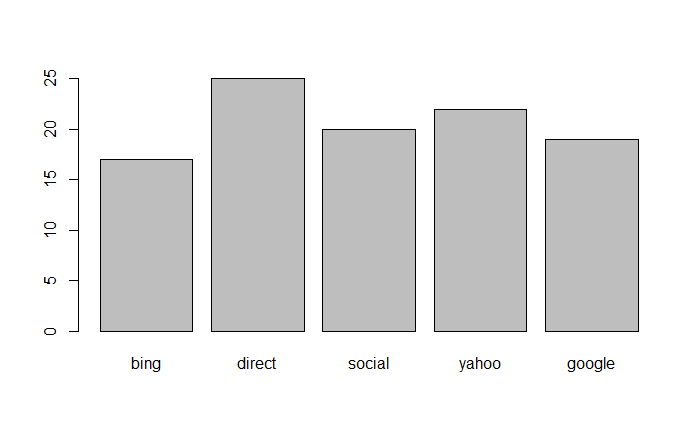

```r
barplot(table(subset(ecom, purchase)$referrer))
```

task 2:creating bar plot using pipe operator.

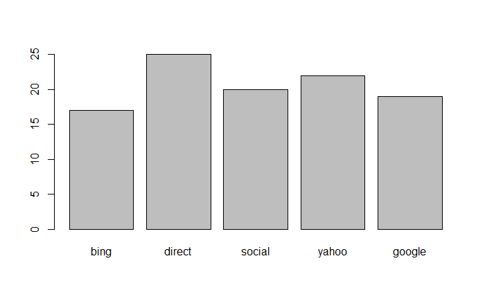

```r
ecom %>%
  subset(purchase) %>%
  extract('referrer') %>%
  table() %>%
  barplot()
```

## Correlation

task 1:Calculating correlation.

```r
ecom1 <- subset(ecom, purchase)
cor(ecom1$n_pages, ecom1$duration)
```

```
[1] 0.4290905
```

task 2:Calculating correlation with pipe.

```r
ecom %>%
  subset(purchase) %$%
  cor(n_pages, duration)
```

```
[1] 0.4290905
```

## Regression

task 1:Calculating Regression.

```r
summary(lm(duration ~ n_pages, data = ecom))
```

```
Call:
lm(formula = duration ~ n_pages, data = ecom)

Residuals:
    Min      1Q  Median      3Q     Max
-386.45 -213.03  -38.93  179.31  602.55

Coefficients:
            Estimate Std. Error t value Pr(>|t|)
(Intercept)  404.803     11.323  35.750  < 2e-16 ***
n_pages       -8.355      1.296  -6.449 1.76e-10 ***
---
Signif. codes:  0 ‘***’ 0.001 ‘**’ 0.01 ‘*’ 0.05 ‘.’ 0.1 ‘ ’ 1

Residual standard error: 263.3 on 998 degrees of freedom
Multiple R-squared:   0.04, Adjusted R-squared:  0.03904
F-statistic: 41.58 on 1 and 998 DF,  p-value: 1.756e-10
```

task 2:Calculating Regression using pipe operator.

```r
ecom %$%
  lm(duration ~ n_pages) %>%
  summary()
```

```
Call:
lm(formula = duration ~ n_pages)

Residuals:
    Min      1Q  Median      3Q     Max
-386.45 -213.03  -38.93  179.31  602.55

Coefficients:
            Estimate Std. Error t value Pr(>|t|)
(Intercept)  404.803     11.323  35.750  < 2e-16 ***
n_pages       -8.355      1.296  -6.449 1.76e-10 ***
---
Signif. codes:  0 ‘***’ 0.001 ‘**’ 0.01 ‘*’ 0.05 ‘.’ 0.1 ‘ ’ 1

Residual standard error: 263.3 on 998 degrees of freedom
Multiple R-squared:   0.04, Adjusted R-squared:  0.03904
F-statistic: 41.58 on 1 and 998 DF,  p-value: 1.756e-10
```

## String Manipulation

task 1:Extracting the first name (jovial) from the below email id and convert it to upper case.

```r
email <- 'jovialcann@anymail.com'

# without pipe
str_to_upper(str_sub(str_split(email, '@')[[1]][1], start = 1, end = 6))
```

```
[1] "JOVIAL"
```

```r
# with pipe
email %>%
  str_split(pattern = '@') %>%
  extract2(1) %>%
  extract(1) %>%
  str_sub(start = 1, end = 6) %>%
  str_to_upper()
```

```
[1] "JOVIAL"
```

task 2:Using another method that uses map_chr() from the purrr package.

```r
email %>%
  str_split(pattern = '@') %>%
  map_chr(1) %>%
  str_sub(start = 1, end = 6) %>%
  str_to_upper()
```

```
[1] "JOVIAL"
```

## Data Extraction

task 1:Displaying n_pages.

```r
ecom_mini['n_pages']
```

| n_pages |
| --- |
| 1 |
| 1 |
| 1 |
| 2 |
| 1 |
| 3 |
| 1 |
| 1 |
| 1 |
| 1 |

task 2:Extracting columns using their name.

```r
extract(ecom_mini, 'n_pages')
```

| n_pages |
| --- |
| 1 |
| 1 |
| 1 |
| 2 |
| 1 |
| 3 |
| 1 |
| 1 |
| 1 |
| 1 |

task 3:Displaying using their index position.

```r
ecom_mini[2]
```

| n_pages |
| --- |
| 1 |
| 1 |
| 1 |
| 2 |
| 1 |
| 3 |
| 1 |
| 1 |
| 1 |
| 1 |

task 4:Extracting columns using their index position.

```r
extract(ecom_mini, 2)
```

| n_pages |
| --- |
| 1 |
| 1 |
| 1 |
| 2 |
| 1 |
| 3 |
| 1 |
| 1 |
| 1 |
| 1 |

task 5:$ will also return a atomic vector.

```r
ecom_mini$n_pages
```

```
 [1] 1 1 1 2 1 3 1 1 1 1
```

task 6:Using use_series() in place of $.

```r
use_series(ecom_mini, 'n_pages')
```

```
 [1] 1 1 1 2 1 3 1 1 1 1
```

task 7:converting ecom_mini into a list using as.list() .

```r
ecom_list <- as.list(ecom_mini)
```

task 8:Extracting elements of a list using [[ ]].

```r
ecom_list[['n_pages']]
```

```
 [1] 1 1 1 2 1 3 1 1 1 1
```

task 9:Extracting elements of a list using extract2().

```r
extract2(ecom_list, 'n_pages')
```

```
 [1] 1 1 1 2 1 3 1 1 1 1
```

task 10:Extracting elements using index position.

```r
ecom_list[[1]]
```

```
 [1] social bing   direct yahoo  direct social social bing   yahoo  google
Levels: bing direct social yahoo google
```

```r
extract2(ecom_list, 1)
```

```
 [1] social bing   direct yahoo  direct social social bing   yahoo  google
Levels: bing direct social yahoo google
```

task 11:Extracting the elements of a list using use_series() .

```r
ecom_list$n_pages
```

```
 [1] 1 1 1 2 1 3 1 1 1 1
```

```r
use_series(ecom_list, n_pages)
```

```
 [1] 1 1 1 2 1 3 1 1 1 1
```

## Arithmetic Operations

task 1:Adding the data using different methods.

```r
1:10 + 1
```

```
 [1]  2  3  4  5  6  7  8  9 10 11
```

```r
add(1:10, 1)
```

```
 [1]  2  3  4  5  6  7  8  9 10 11
```

```r
`+`(1:10, 1)
```

```
 [1]  2  3  4  5  6  7  8  9 10 11
```

task 2:Multiplying the data using different methods.

```r
1:10 * 3
```

```
 [1]  3  6  9 12 15 18 21 24 27 30
```

```r
multiply_by(1:10, 3)
```

```
 [1]  3  6  9 12 15 18 21 24 27 30
```

```r
`*`(1:10, 3)
```

```
 [1]  3  6  9 12 15 18 21 24 27 30
```

task 3:Dividing the data using different methods.

```r
1:10 / 2
```

```
 [1] 0.5 1.0 1.5 2.0 2.5 3.0 3.5 4.0 4.5 5.0
```

```r
divide_by(1:10, 2)
```

```
 [1] 0.5 1.0 1.5 2.0 2.5 3.0 3.5 4.0 4.5 5.0
```

```r
`/`(1:10, 2)
```

```
 [1] 0.5 1.0 1.5 2.0 2.5 3.0 3.5 4.0 4.5 5.0
```

```r
1:10 ^ 2
```

```
  [1]   1   2   3   4   5   6   7   8   9  10  11  12  13  14  15  16  17  18  19  20  21  22  23  24  25  26
 [27]  27  28  29  30  31  32  33  34  35  36  37  38  39  40  41  42  43  44  45  46  47  48  49  50  51  52
 [53]  53  54  55  56  57  58  59  60  61  62  63  64  65  66  67  68  69  70  71  72  73  74  75  76  77  78
 [79]  79  80  81  82  83  84  85  86  87  88  89  90  91  92  93  94  95  96  97  98  99 100
```

```r
raise_to_power(1:10, 2)
```

```
 [1]   1   4   9  16  25  36  49  64  81 100
```

```r
`^`(1:10, 2)
```

```
 [1]   1   4   9  16  25  36  49  64  81 100
```

## Logical Operators

task 1:Using greater than in different methods.

```r
1:10 > 5
```

```
 [1] FALSE FALSE FALSE FALSE FALSE  TRUE  TRUE  TRUE  TRUE  TRUE
```

```r
is_greater_than(1:10, 5)
```

```
 [1] FALSE FALSE FALSE FALSE FALSE  TRUE  TRUE  TRUE  TRUE  TRUE
```

```r
`>`(1:10, 5)
```

```
 [1] FALSE FALSE FALSE FALSE FALSE  TRUE  TRUE  TRUE  TRUE  TRUE
```

task 3:Using weakly greater than in different methods.

```r
1:10 >= 5
```

```
 [1] FALSE FALSE FALSE FALSE  TRUE  TRUE  TRUE  TRUE  TRUE  TRUE
```

```r
is_weakly_greater_than(1:10, 5)
```

```
 [1] FALSE FALSE FALSE FALSE  TRUE  TRUE  TRUE  TRUE  TRUE  TRUE
```

```r
`>=`(1:10, 5)
```

```
 [1] FALSE FALSE FALSE FALSE  TRUE  TRUE  TRUE  TRUE  TRUE  TRUE
```

# tibbles

task 1:Loading the library.

```r
library(tibble)
library(dplyr)
```

task 2:Creating tibbles

```r
tibble(x = letters,
       y = 1:26,
       z = sample(100, 26))
```

| x | y | z |
| --- | --- | --- |
| a | 1 | 37 |
| b | 2 | 7 |
| c | 3 | 41 |
| d | 4 | 52 |
| e | 5 | 75 |
| f | 6 | 48 |
| g | 7 | 19 |
| h | 8 | 29 |
| i | 9 | 58 |
| j | 10 | 82 |

[output cut: 16 more lines]

## tibble features

task 1:never changes input’s types.

```r
tibble(x = letters,
       y = 1:26,
       z = sample(100, 26))
```

| x | y | z |
| --- | --- | --- |
| a | 1 | 64 |
| b | 2 | 59 |
| c | 3 | 38 |
| d | 4 | 6 |
| e | 5 | 58 |
| f | 6 | 2 |
| g | 7 | 67 |
| h | 8 | 46 |
| i | 9 | 61 |
| j | 10 | 70 |

[output cut: 16 more lines]

task 2:never adjusts variable names.

```r
names(data.frame(`order value` = 10))
```

```
[1] "order.value"
```

```r
names(tibble(`order value` = 10))
```

```
[1] "order value"
```

task 3:never prints all rows.

```r
x <- 1:100
y <- letters[1]
z <- sample(c(TRUE, FALSE), 100, replace = TRUE)
tibble(x, y, z)
```

| x | y | z |
| --- | --- | --- |
| 1 | a | FALSE |
| 2 | a | FALSE |
| 3 | a | FALSE |
| 4 | a | TRUE |
| 5 | a | TRUE |
| 6 | a | FALSE |
| 7 | a | TRUE |
| 8 | a | TRUE |
| 9 | a | TRUE |
| 10 | a | FALSE |

[output cut: 90 more lines]

task 4:Never recycles vector of length greater than 1

```r
x <- 1:100
y <- letters
z <- sample(c(TRUE, FALSE), 100, replace = TRUE)
tibble(x, y, z)
```

```
Error in `tibble()`:
! Tibble columns must have compatible sizes.
• Size 100: Existing data.
• Size 26: Column at position 2.
ℹ Only values of size one are recycled.
Backtrace:
 1. tibble::tibble(x, y, z)
```

task 5:Testing if an object is a tibble using is_tibble().

```r
is_tibble(mtcars)
```

```
[1] FALSE
```

```r
is_tibble(as_tibble(mtcars))
```

```
[1] TRUE
```

task 7:Creating tibbles is using tribble()

```r
tribble(
  ~x, ~y, ~z,
  #--|--|----
  1, TRUE, 'a',
  2, FALSE, 'b'
)
```

| x | y | z |
| --- | --- | --- |
| 1 | TRUE | a |
| 2 | FALSE | b |

task 8:Names of the columns in tibbles

```r
tibble(
  ` ` = 'space',
  `2` = 'integer',
  `:)` = 'smiley'
)
```

|  | 2 | :) |
| --- | --- | --- |
| space | integer | smiley |

task 9:Adding data related to Safari browser to the web traffic data using add_row().

```r
browsers <- enframe(c(chrome = 40, firefox = 20, edge = 30))
browsers
```

| name | value |
| --- | --- |
| chrome | 40 |
| firefox | 20 |
| edge | 30 |

```r
add_row(browsers, name = 'safari', value = 10)
```

| name | value |
| --- | --- |
| chrome | 40 |
| firefox | 20 |
| edge | 30 |
| safari | 10 |

task 10:Changing the safari from last to the second.

```r
add_row(browsers, name = 'safari', value = 10, .before = 2)
```

| name | value |
| --- | --- |
| chrome | 40 |
| safari | 10 |
| firefox | 20 |
| edge | 30 |

task 11:Adding the new columns using add_columns()

```r
browsers <- enframe(c(chrome = 40, firefox = 20, edge = 30, safari = 10))
add_column(browsers, visits = c(4000, 2000, 3000, 1000))
```

| name | value | visits |
| --- | --- | --- |
| chrome | 40 | 4000 |
| firefox | 20 | 2000 |
| edge | 30 | 3000 |
| safari | 10 | 1000 |

task 12:Checking whether a data set has rownames, using has_rownames().

```r
has_rownames(mtcars)
```

```
[1] TRUE
```

task 13:Removing Rownames.

```r
remove_rownames(mtcars)
```

| mpg | cyl | disp | hp | drat | wt | qsec | vs | am | gear | carb |
| --- | --- | --- | --- | --- | --- | --- | --- | --- | --- | --- |
| 21.0 | 6 | 160.0 | 110 | 3.90 | 2.620 | 16.46 | 0 | 1 | 4 | 4 |
| 21.0 | 6 | 160.0 | 110 | 3.90 | 2.875 | 17.02 | 0 | 1 | 4 | 4 |
| 22.8 | 4 | 108.0 | 93 | 3.85 | 2.320 | 18.61 | 1 | 1 | 4 | 1 |
| 21.4 | 6 | 258.0 | 110 | 3.08 | 3.215 | 19.44 | 1 | 0 | 3 | 1 |
| 18.7 | 8 | 360.0 | 175 | 3.15 | 3.440 | 17.02 | 0 | 0 | 3 | 2 |
| 18.1 | 6 | 225.0 | 105 | 2.76 | 3.460 | 20.22 | 1 | 0 | 3 | 1 |
| 14.3 | 8 | 360.0 | 245 | 3.21 | 3.570 | 15.84 | 0 | 0 | 3 | 4 |
| 24.4 | 4 | 146.7 | 62 | 3.69 | 3.190 | 20.00 | 1 | 0 | 4 | 2 |
| 22.8 | 4 | 140.8 | 95 | 3.92 | 3.150 | 22.90 | 1 | 0 | 4 | 2 |
| 19.2 | 6 | 167.6 | 123 | 3.92 | 3.440 | 18.30 | 1 | 0 | 4 | 4 |

[output cut: 22 more lines]

task 14:Rownames to Column.

```r
head(rownames_to_column(mtcars))
```

|  | rowname | mpg | cyl | disp | hp | drat | wt | qsec | vs | am | gear | carb |
| --- | --- | --- | --- | --- | --- | --- | --- | --- | --- | --- | --- | --- |
| 1 | Mazda RX4 | 21.0 | 6 | 160 | 110 | 3.90 | 2.620 | 16.46 | 0 | 1 | 4 | 4 |
| 2 | Mazda RX4 Wag | 21.0 | 6 | 160 | 110 | 3.90 | 2.875 | 17.02 | 0 | 1 | 4 | 4 |
| 3 | Datsun 710 | 22.8 | 4 | 108 | 93 | 3.85 | 2.320 | 18.61 | 1 | 1 | 4 | 1 |
| 4 | Hornet 4 Drive | 21.4 | 6 | 258 | 110 | 3.08 | 3.215 | 19.44 | 1 | 0 | 3 | 1 |
| 5 | Hornet Sportabout | 18.7 | 8 | 360 | 175 | 3.15 | 3.440 | 17.02 | 0 | 0 | 3 | 2 |
| 6 | Valiant | 18.1 | 6 | 225 | 105 | 2.76 | 3.460 | 20.22 | 1 | 0 | 3 | 1 |

task 15:Converting the first column in the data set to rownames, use column_to_rownames():

```r
mtcars_tbl <- rownames_to_column(mtcars)
column_to_rownames(mtcars_tbl)
```

|  | mpg | cyl | disp | hp | drat | wt | qsec | vs | am | gear | carb |
| --- | --- | --- | --- | --- | --- | --- | --- | --- | --- | --- | --- |
| Mazda RX4 | 21.0 | 6 | 160.0 | 110 | 3.90 | 2.620 | 16.46 | 0 | 1 | 4 | 4 |
| Mazda RX4 Wag | 21.0 | 6 | 160.0 | 110 | 3.90 | 2.875 | 17.02 | 0 | 1 | 4 | 4 |
| Datsun 710 | 22.8 | 4 | 108.0 | 93 | 3.85 | 2.320 | 18.61 | 1 | 1 | 4 | 1 |
| Hornet 4 Drive | 21.4 | 6 | 258.0 | 110 | 3.08 | 3.215 | 19.44 | 1 | 0 | 3 | 1 |
| Hornet Sportabout | 18.7 | 8 | 360.0 | 175 | 3.15 | 3.440 | 17.02 | 0 | 0 | 3 | 2 |
| Valiant | 18.1 | 6 | 225.0 | 105 | 2.76 | 3.460 | 20.22 | 1 | 0 | 3 | 1 |
| Duster 360 | 14.3 | 8 | 360.0 | 245 | 3.21 | 3.570 | 15.84 | 0 | 0 | 3 | 4 |
| Merc 240D | 24.4 | 4 | 146.7 | 62 | 3.69 | 3.190 | 20.00 | 1 | 0 | 4 | 2 |
| Merc 230 | 22.8 | 4 | 140.8 | 95 | 3.92 | 3.150 | 22.90 | 1 | 0 | 4 | 2 |
| Merc 280 | 19.2 | 6 | 167.6 | 123 | 3.92 | 3.440 | 18.30 | 1 | 0 | 4 | 4 |

[output cut: 22 more lines]

task 16:Using glimpse() to get an overview of the data.

```r
glimpse(mtcars)
```

```
Rows: 32
Columns: 11
$ mpg  <dbl> 21.0, 21.0, 22.8, 21.4, 18.7, 18.1, 14.3, 24.4, 22.8, 19.2, 17.8, 16.4, 17.3, 15.2, 10.4, 10.4…
$ cyl  <dbl> 6, 6, 4, 6, 8, 6, 8, 4, 4, 6, 6, 8, 8, 8, 8, 8, 8, 4, 4, 4, 4, 8, 8, 8, 8, 4, 4, 4, 8, 6, 8, 4
$ disp <dbl> 160.0, 160.0, 108.0, 258.0, 360.0, 225.0, 360.0, 146.7, 140.8, 167.6, 167.6, 275.8, 275.8, 275…
$ hp   <dbl> 110, 110, 93, 110, 175, 105, 245, 62, 95, 123, 123, 180, 180, 180, 205, 215, 230, 66, 52, 65, …
$ drat <dbl> 3.90, 3.90, 3.85, 3.08, 3.15, 2.76, 3.21, 3.69, 3.92, 3.92, 3.92, 3.07, 3.07, 3.07, 2.93, 3.00…
$ wt   <dbl> 2.620, 2.875, 2.320, 3.215, 3.440, 3.460, 3.570, 3.190, 3.150, 3.440, 3.440, 4.070, 3.730, 3.7…
$ qsec <dbl> 16.46, 17.02, 18.61, 19.44, 17.02, 20.22, 15.84, 20.00, 22.90, 18.30, 18.90, 17.40, 17.60, 18.…
$ vs   <dbl> 0, 0, 1, 1, 0, 1, 0, 1, 1, 1, 1, 0, 0, 0, 0, 0, 0, 1, 1, 1, 1, 0, 0, 0, 0, 1, 0, 1, 0, 0, 0, 1
$ am   <dbl> 1, 1, 1, 0, 0, 0, 0, 0, 0, 0, 0, 0, 0, 0, 0, 0, 0, 1, 1, 1, 0, 0, 0, 0, 0, 1, 1, 1, 1, 1, 1, 1
$ gear <dbl> 4, 4, 4, 3, 3, 3, 3, 4, 4, 4, 4, 3, 3, 3, 3, 3, 3, 4, 4, 4, 3, 3, 3, 3, 3, 4, 5, 5, 5, 5, 5, 4
$ carb <dbl> 4, 4, 1, 1, 2, 1, 4, 2, 2, 4, 4, 3, 3, 3, 4, 4, 4, 1, 2, 1, 1, 2, 2, 4, 2, 1, 2, 2, 4, 6, 8, 2
```

task 17:Checking if a tibble has a specific column using has_name().

```r
has_name(mtcars, 'cyl')
```

```
[1] TRUE
```

```r
has_name(mtcars, 'gears')
```

```
[1] FALSE
```

# Hacking Strings

task 1:Loading the library.

```r
library(stringr)
library(tibble)
library(magrittr)
library(purrr)
library(dplyr)
library(readr)
```

task 2:Importing the data.

```r
mockstring <- read_csv('https://raw.githubusercontent.com/rsquaredacademy/datasets/master/mock_strings.csv')
mockstring
```

| id | image_url | domain | imageurl | email | filename | phone | address | url | full_name | currency | passwords |
| --- | --- | --- | --- | --- | --- | --- | --- | --- | --- | --- | --- |
| 1 | https://robohash.org/providentassumendaexplicabo.jpg?size=50x50&set=set1 | addtoany.com | http://dummyimage.com/130x183.jpg/dddddd/000000 | mnewburn0@fastcompany.com | PedeMalesuada.xls | 66-(777)902-6181 | 8 Anhalt Crossing | https://engadget.com/nascetur/ridiculus/mus/vivamus/vestibulum.jsp?eu=est&tincidunt=risus&in=auctor&leo=sed&maecenas=tristique&pulvinar=in&lobortis=tempus&est=sit&phasellus=amet&sit=sem&amet=fusce&era… | Mufi Ruit | ¥34.37 | VybPYpEXUjJh6nQk |
| 2 | https://robohash.org/etillumvoluptate.jpg?size=50x50&set=set1 | gmpg.org | http://dummyimage.com/106x217.bmp/dddddd/000000 | mdankersley1@digg.com | LobortisVel.mp3 | 351-(422)736-6807 | 697 East Avenue | http://delicious.com/phasellus/in/felis/donec.json?interdum=risus&mauris=dapibus&non=augue&ligula=vel&pellentesque=accumsan&ultrices=tellus&phasellus=nisi&id=eu&sapien=orci&in=mauris&sapien=lacinia&ia… | Leese Furmagier | $67.37 | mxET3n6dz42X8YUv |
| 3 | https://robohash.org/nonoptiovoluptatibus.jpg?size=50x50&set=set1 | samsung.com | http://dummyimage.com/146x127.bmp/cc0000/ffffff | hgirhard2@altervista.org | CongueDiamId.pdf | 33-(371)684-5114 | 89 Dottie Circle | https://w3.org/sed/augue/aliquam/erat/volutpat.json?dictumst=mi&morbi=sit&vestibulum=amet&velit=lobortis&id=sapien&pretium=sapien&iaculis=non&diam=mi&erat=integer&fermentum=ac&justo=neque&nec=duis&con… | Blakelee Wilshire | €33,85 | Z9f4WeNVQ28FwKML |
| 4 | https://robohash.org/voluptatumauthic.jpg?size=50x50&set=set1 | spotify.com | http://dummyimage.com/181x194.png/5fa2dd/ffffff | pmcmenamy3@sciencedirect.com | EleifendQuam.avi | 86-(410)823-6712 | 98135 Blue Bill Park Drive | http://indiatimes.com/pede/lobortis/ligula/sit/amet.jpg?quam=nullam&sollicitudin=porttitor&vitae=lacus&consectetuer=at&eget=turpis&rutrum=donec&at=posuere&lorem=metus&integer=vitae&tincidunt=ipsum&ant… | Terencio McIllrick | €42,89 | Ndbm8nwCps6jUze3 |
| 5 | https://robohash.org/placeaterrorqui.jpg?size=50x50&set=set1 | wunderground.com | http://dummyimage.com/220x123.jpg/ff4444/ffffff | drisbrough4@bandcamp.com | PurusPhasellus.mp3 | 223-(518)814-6361 | 7814 Pennsylvania Street | https://tumblr.com/id/mauris/vulputate/elementum.png?tincidunt=maecenas&eget=pulvinar&tempus=lobortis&vel=est&pede=phasellus&morbi=sit&porttitor=amet&lorem=erat&id=nulla&ligula=tempus&suspendisse=viva… | Debee McErlaine | €13,19 | U3Lj9xJw8NHzB5Sg |
| 6 | https://robohash.org/temporeutea.jpg?size=50x50&set=set1 | alexa.com | http://dummyimage.com/118x176.bmp/dddddd/000000 | cphlippi5@surveymonkey.com | ElementumInHac.avi | 420-(760)354-8671 | 4897 Little Fleur Drive | https://unblog.fr/est/quam/pharetra.jpg?amet=phasellus&erat=sit&nulla=amet&tempus=erat&vivamus=nulla&in=tempus&felis=vivamus&eu=in&sapien=felis&cursus=eu&vestibulum=sapien&proin=cursus&eu=vestibulum&m… | Fran Painten | ¥87.35 | KEhVAC3QNvjWDFJ7 |
| 7 | https://robohash.org/maximesaepequi.bmp?size=50x50&set=set1 | google.it | http://dummyimage.com/185x202.jpg/ff4444/ffffff | kdodswell6@un.org | Mattis.doc | 1-(712)615-2879 | 53541 Morrow Center | http://vinaora.com/posuere.jpg?convallis=in&nulla=faucibus&neque=orci&libero=luctus&convallis=et&eget=ultrices&eleifend=posuere&luctus=cubilia&ultricies=curae&eu=duis&nibh=faucibus&quisque=accumsan&id… | Frasco Bowich | $34.89 | jydGPCW7fa2bZpU4 |
| 8 | https://robohash.org/nemoautesse.png?size=50x50&set=set1 | ed.gov | http://dummyimage.com/223x163.jpg/ff4444/ffffff | vhourihane7@ovh.net | PurusEu.tiff | 62-(437)705-1118 | 4819 Hermina Parkway | https://globo.com/accumsan.png?elementum=eu&pellentesque=mi&quisque=nulla&porta=ac&volutpat=enim&erat=in&quisque=tempor&erat=turpis&eros=nec&viverra=euismod&eget=scelerisque&congue=quam&eget=turpis&se… | Car Ponten | ¥41.66 | pytVHesNZjAL8WKc |
| 9 | https://robohash.org/odiorerumaut.png?size=50x50&set=set1 | jigsy.com | http://dummyimage.com/145x113.jpg/5fa2dd/ffffff | rdike8@timesonline.co.uk | JustoEtiamPretium.xls | 1-(683)965-1323 | 68096 Monument Park | https://xing.com/elementum/eu/interdum/eu/tincidunt.html?sit=proin&amet=eu&sapien=mi&dignissim=nulla&vestibulum=ac&vestibulum=enim&ante=in&ipsum=tempor&primis=turpis&in=nec&faucibus=euismod&orci=scele… | Tades Checcucci | €70,80 | Rsw4EQGk9tKTnzDp |
| 10 | https://robohash.org/omnismolestiaearchitecto.png?size=50x50&set=set1 | jugem.jp | http://dummyimage.com/238x214.png/cc0000/ffffff | tdudbridge9@clickbank.net | Ante.tiff | 30-(553)559-7448 | 9595 Spaight Avenue | https://bigcartel.com/tortor/quis/turpis/sed/ante/vivamus.html?in=lorem&eleifend=quisque&quam=ut&a=erat&odio=curabitur&in=gravida&hac=nisi&habitasse=at&platea=nibh&dictumst=in&maecenas=hac&ut=habitass… | Wilton Kemmey | €62,76 | KvrNGQ7yL3pfsaZA |

[output cut: 990 more lines]

task 3:use a smaller data (i.e. 1st 10 rows)

```r
mockdata <- slice(mockstring, 1:10)
mockdata
```

| id | image_url | domain | imageurl | email | filename | phone | address | url | full_name | currency | passwords |
| --- | --- | --- | --- | --- | --- | --- | --- | --- | --- | --- | --- |
| 1 | https://robohash.org/providentassumendaexplicabo.jpg?size=50x50&set=set1 | addtoany.com | http://dummyimage.com/130x183.jpg/dddddd/000000 | mnewburn0@fastcompany.com | PedeMalesuada.xls | 66-(777)902-6181 | 8 Anhalt Crossing | https://engadget.com/nascetur/ridiculus/mus/vivamus/vestibulum.jsp?eu=est&tincidunt=risus&in=auctor&leo=sed&maecenas=tristique&pulvinar=in&lobortis=tempus&est=sit&phasellus=amet&sit=sem&amet=fusce&era… | Mufi Ruit | ¥34.37 | VybPYpEXUjJh6nQk |
| 2 | https://robohash.org/etillumvoluptate.jpg?size=50x50&set=set1 | gmpg.org | http://dummyimage.com/106x217.bmp/dddddd/000000 | mdankersley1@digg.com | LobortisVel.mp3 | 351-(422)736-6807 | 697 East Avenue | http://delicious.com/phasellus/in/felis/donec.json?interdum=risus&mauris=dapibus&non=augue&ligula=vel&pellentesque=accumsan&ultrices=tellus&phasellus=nisi&id=eu&sapien=orci&in=mauris&sapien=lacinia&ia… | Leese Furmagier | $67.37 | mxET3n6dz42X8YUv |
| 3 | https://robohash.org/nonoptiovoluptatibus.jpg?size=50x50&set=set1 | samsung.com | http://dummyimage.com/146x127.bmp/cc0000/ffffff | hgirhard2@altervista.org | CongueDiamId.pdf | 33-(371)684-5114 | 89 Dottie Circle | https://w3.org/sed/augue/aliquam/erat/volutpat.json?dictumst=mi&morbi=sit&vestibulum=amet&velit=lobortis&id=sapien&pretium=sapien&iaculis=non&diam=mi&erat=integer&fermentum=ac&justo=neque&nec=duis&con… | Blakelee Wilshire | €33,85 | Z9f4WeNVQ28FwKML |
| 4 | https://robohash.org/voluptatumauthic.jpg?size=50x50&set=set1 | spotify.com | http://dummyimage.com/181x194.png/5fa2dd/ffffff | pmcmenamy3@sciencedirect.com | EleifendQuam.avi | 86-(410)823-6712 | 98135 Blue Bill Park Drive | http://indiatimes.com/pede/lobortis/ligula/sit/amet.jpg?quam=nullam&sollicitudin=porttitor&vitae=lacus&consectetuer=at&eget=turpis&rutrum=donec&at=posuere&lorem=metus&integer=vitae&tincidunt=ipsum&ant… | Terencio McIllrick | €42,89 | Ndbm8nwCps6jUze3 |
| 5 | https://robohash.org/placeaterrorqui.jpg?size=50x50&set=set1 | wunderground.com | http://dummyimage.com/220x123.jpg/ff4444/ffffff | drisbrough4@bandcamp.com | PurusPhasellus.mp3 | 223-(518)814-6361 | 7814 Pennsylvania Street | https://tumblr.com/id/mauris/vulputate/elementum.png?tincidunt=maecenas&eget=pulvinar&tempus=lobortis&vel=est&pede=phasellus&morbi=sit&porttitor=amet&lorem=erat&id=nulla&ligula=tempus&suspendisse=viva… | Debee McErlaine | €13,19 | U3Lj9xJw8NHzB5Sg |
| 6 | https://robohash.org/temporeutea.jpg?size=50x50&set=set1 | alexa.com | http://dummyimage.com/118x176.bmp/dddddd/000000 | cphlippi5@surveymonkey.com | ElementumInHac.avi | 420-(760)354-8671 | 4897 Little Fleur Drive | https://unblog.fr/est/quam/pharetra.jpg?amet=phasellus&erat=sit&nulla=amet&tempus=erat&vivamus=nulla&in=tempus&felis=vivamus&eu=in&sapien=felis&cursus=eu&vestibulum=sapien&proin=cursus&eu=vestibulum&m… | Fran Painten | ¥87.35 | KEhVAC3QNvjWDFJ7 |
| 7 | https://robohash.org/maximesaepequi.bmp?size=50x50&set=set1 | google.it | http://dummyimage.com/185x202.jpg/ff4444/ffffff | kdodswell6@un.org | Mattis.doc | 1-(712)615-2879 | 53541 Morrow Center | http://vinaora.com/posuere.jpg?convallis=in&nulla=faucibus&neque=orci&libero=luctus&convallis=et&eget=ultrices&eleifend=posuere&luctus=cubilia&ultricies=curae&eu=duis&nibh=faucibus&quisque=accumsan&id… | Frasco Bowich | $34.89 | jydGPCW7fa2bZpU4 |
| 8 | https://robohash.org/nemoautesse.png?size=50x50&set=set1 | ed.gov | http://dummyimage.com/223x163.jpg/ff4444/ffffff | vhourihane7@ovh.net | PurusEu.tiff | 62-(437)705-1118 | 4819 Hermina Parkway | https://globo.com/accumsan.png?elementum=eu&pellentesque=mi&quisque=nulla&porta=ac&volutpat=enim&erat=in&quisque=tempor&erat=turpis&eros=nec&viverra=euismod&eget=scelerisque&congue=quam&eget=turpis&se… | Car Ponten | ¥41.66 | pytVHesNZjAL8WKc |
| 9 | https://robohash.org/odiorerumaut.png?size=50x50&set=set1 | jigsy.com | http://dummyimage.com/145x113.jpg/5fa2dd/ffffff | rdike8@timesonline.co.uk | JustoEtiamPretium.xls | 1-(683)965-1323 | 68096 Monument Park | https://xing.com/elementum/eu/interdum/eu/tincidunt.html?sit=proin&amet=eu&sapien=mi&dignissim=nulla&vestibulum=ac&vestibulum=enim&ante=in&ipsum=tempor&primis=turpis&in=nec&faucibus=euismod&orci=scele… | Tades Checcucci | €70,80 | Rsw4EQGk9tKTnzDp |
| 10 | https://robohash.org/omnismolestiaearchitecto.png?size=50x50&set=set1 | jugem.jp | http://dummyimage.com/238x214.png/cc0000/ffffff | tdudbridge9@clickbank.net | Ante.tiff | 30-(553)559-7448 | 9595 Spaight Avenue | https://bigcartel.com/tortor/quis/turpis/sed/ante/vivamus.html?in=lorem&eleifend=quisque&quam=ut&a=erat&odio=curabitur&in=gravida&hac=nisi&habitasse=at&platea=nibh&dictumst=in&maecenas=hac&ut=habitass… | Wilton Kemmey | €62,76 | KvrNGQ7yL3pfsaZA |

task 4:Using str_detect() to detect @ .

```r
str_detect(mockdata$email, pattern = "@")
```

```
 [1] TRUE TRUE TRUE TRUE TRUE TRUE TRUE TRUE TRUE TRUE
```

task 6:Using str_c() to concatenate strings, adding the string email id: before each email id in the data set.

```r
str_c("email id:", mockdata$email)
```

```
 [1] "email id:mnewburn0@fastcompany.com"    "email id:mdankersley1@digg.com"
 [3] "email id:hgirhard2@altervista.org"     "email id:pmcmenamy3@sciencedirect.com"
 [5] "email id:drisbrough4@bandcamp.com"     "email id:cphlippi5@surveymonkey.com"
 [7] "email id:kdodswell6@un.org"            "email id:vhourihane7@ovh.net"
 [9] "email id:rdike8@timesonline.co.uk"     "email id:tdudbridge9@clickbank.net"
```

task 7:spliting domain name and extension from the domain column.

```r
str_split(mockdata$domain, pattern = "\\.")
```

```
[[1]]
[1] "addtoany" "com"

[[2]]
[1] "gmpg" "org"

[[3]]
[1] "samsung" "com"

[[4]]
[1] "spotify" "com"

[[5]]
[1] "wunderground" "com"

[[6]]
[1] "alexa" "com"

[[7]]
[1] "google" "it"

[[8]]
[1] "ed"  "gov"

[[9]]
[1] "jigsy" "com"

[[10]]
[1] "jugem" "jp"
```

task 8:It truncates each email address in the ‘email’ column of the ‘mockdata’ dataframe to a maximum width of 10 characters.

```r
str_trunc(mockdata$email, width = 10)
```

```
 [1] "mnewbur..." "mdanker..." "hgirhar..." "pmcmena..." "drisbro..." "cphlipp..." "kdodswe..." "vhourih..."
 [9] "rdike8@..." "tdudbri..."
```

```r
str_trunc(mockdata$email, width = 10, side = "left")
```

```
 [1] "...any.com" "...igg.com" "...sta.org" "...ect.com" "...amp.com" "...key.com" "...@un.org" "...ovh.net"
 [9] "...e.co.uk" "...ank.net"
```

```r
str_trunc(mockdata$email, width = 10, side = "center")
```

```
 [1] "mnew...com" "mdan...com" "hgir...org" "pmcm...com" "dris...com" "cphl...com" "kdod...org" "vhou...net"
 [9] "rdik....uk" "tdud...net"
```

task 9:quickly sort the emails in both ascending and descending orders.

```r
str_sort(mockdata$email)
```

```
 [1] "cphlippi5@surveymonkey.com"   "drisbrough4@bandcamp.com"     "hgirhard2@altervista.org"
 [4] "kdodswell6@un.org"            "mdankersley1@digg.com"        "mnewburn0@fastcompany.com"
 [7] "pmcmenamy3@sciencedirect.com" "rdike8@timesonline.co.uk"     "tdudbridge9@clickbank.net"
[10] "vhourihane7@ovh.net"
```

```r
str_sort(mockdata$email, decreasing = TRUE)
```

```
 [1] "vhourihane7@ovh.net"          "tdudbridge9@clickbank.net"    "rdike8@timesonline.co.uk"
 [4] "pmcmenamy3@sciencedirect.com" "mnewburn0@fastcompany.com"    "mdankersley1@digg.com"
 [7] "kdodswell6@un.org"            "hgirhard2@altervista.org"     "drisbrough4@bandcamp.com"
[10] "cphlippi5@surveymonkey.com"
```

task 10:Making full_name in uppercase.

```r
str_to_upper(mockdata$full_name)
```

```
 [1] "MUFI RUIT"          "LEESE FURMAGIER"    "BLAKELEE WILSHIRE"  "TERENCIO MCILLRICK" "DEBEE MCERLAINE"
 [6] "FRAN PAINTEN"       "FRASCO BOWICH"      "CAR PONTEN"         "TADES CHECCUCCI"    "WILTON KEMMEY"
```

task 11:Making full_name in lowercase.

```r
str_to_lower(mockdata$full_name)
```

```
 [1] "mufi ruit"          "leese furmagier"    "blakelee wilshire"  "terencio mcillrick" "debee mcerlaine"
 [6] "fran painten"       "frasco bowich"      "car ponten"         "tades checcucci"    "wilton kemmey"
```

task 12:Replacing word street with ST.

```r
str_replace(mockdata$address, "Street", "ST")
```

```
 [1] "8 Anhalt Crossing"          "697 East Avenue"            "89 Dottie Circle"
 [4] "98135 Blue Bill Park Drive" "7814 Pennsylvania ST"       "4897 Little Fleur Drive"
 [7] "53541 Morrow Center"        "4819 Hermina Parkway"       "68096 Monument Park"
[10] "9595 Spaight Avenue"
```

task 13:Replacing word Road with RD.

```r
str_replace(mockdata$address, "Road", "RD")
```

```
 [1] "8 Anhalt Crossing"          "697 East Avenue"            "89 Dottie Circle"
 [4] "98135 Blue Bill Park Drive" "7814 Pennsylvania Street"   "4897 Little Fleur Drive"
 [7] "53541 Morrow Center"        "4819 Hermina Parkway"       "68096 Monument Park"
[10] "9595 Spaight Avenue"
```

task 14:Extracting parts of the string that match a particular pattern(org) using str_extract().

```r
str_extract(mockdata$email, pattern = "org")
```

```
 [1] NA    NA    "org" NA    NA    NA    "org" NA    NA    NA
```

task 15:Using str_match() to see if the pattern is present in the string.

```r
str_match(mockdata$email, pattern = "org")
```

```
      [,1]
 [1,] NA
 [2,] NA
 [3,] "org"
 [4,] NA
 [5,] NA
 [6,] NA
 [7,] "org"
 [8,] NA
 [9,] NA
[10,] NA
```

task 16:Using str_which() to identify the index of the strings that match our pattern.

```r
str_which(mockdata$email, pattern = "org")
```

```
[1] 3 7
```

task 17: knowing the position of @ in the email ids,using str_locate().

```r
str_locate(mockdata$email, pattern = "@")
```

```
      start end
 [1,]    10  10
 [2,]    13  13
 [3,]    10  10
 [4,]    11  11
 [5,]    12  12
 [6,]    10  10
 [7,]    11  11
 [8,]    12  12
 [9,]     7   7
[10,]    12  12
```

task 18:Using str_length to ensure that the length of the strings in the password column.

```r
str_length(mockdata$passwords)
```

```
 [1] 16 16 16 16 16 16 16 16 16 16
```

task 19:Extracting the currency type from the currency column.

```r
str_sub(mockdata$currency, start = 1, end = 1)
```

```
 [1] "¥" "$" "€" "€" "€" "¥" "$" "¥" "€" "€"
```

task 20:using it to extract the first name from the full_name column.

```r
word(mockdata$full_name, 1)
```

```
 [1] "Mufi"     "Leese"    "Blakelee" "Terencio" "Debee"    "Fran"     "Frasco"   "Car"      "Tades"
[10] "Wilton"
```

task 21:using it to extract the last name from the full_name column.

```r
word(mockdata$full_name, 2)
```

```
 [1] "Ruit"      "Furmagier" "Wilshire"  "McIllrick" "McErlaine" "Painten"   "Bowich"    "Ponten"
 [9] "Checcucci" "Kemmey"
```

## Extract domain name from email ids

task 1:Displaying emails before we extract the domain names.

```r
emails <-
  mockstring %>%
  pull(email) %>%
  head()

emails
```

```
[1] "mnewburn0@fastcompany.com"    "mdankersley1@digg.com"        "hgirhard2@altervista.org"
[4] "pmcmenamy3@sciencedirect.com" "drisbrough4@bandcamp.com"     "cphlippi5@surveymonkey.com"
```

task 2:Spliting the email using using the pattern @.

```r
 str_split(emails, pattern = '@')
```

```
[[1]]
[1] "mnewburn0"       "fastcompany.com"

[[2]]
[1] "mdankersley1" "digg.com"

[[3]]
[1] "hgirhard2"      "altervista.org"

[[4]]
[1] "pmcmenamy3"        "sciencedirect.com"

[[5]]
[1] "drisbrough4"  "bandcamp.com"

[[6]]
[1] "cphlippi5"        "surveymonkey.com"
```

task 3:Extract the second element from the list.

```r
emails %>%
  str_split(pattern = '@') %>%
  map_chr(2)
```

```
[1] "fastcompany.com"   "digg.com"          "altervista.org"    "sciencedirect.com" "bandcamp.com"
[6] "surveymonkey.com"
```

task 4:Spliting the above using pattern \..

```r
emails %>%
  str_split(pattern = '@') %>%
  map_chr(2) %>%
  str_split(pattern = '\\.')
```

```
[[1]]
[1] "fastcompany" "com"

[[2]]
[1] "digg" "com"

[[3]]
[1] "altervista" "org"

[[4]]
[1] "sciencedirect" "com"

[[5]]
[1] "bandcamp" "com"

[[6]]
[1] "surveymonkey" "com"
```

task 5:Extracting the first element from the list.

```r
emails %>%
  str_split(pattern = '@') %>%
  map_chr(2) %>%
  str_split(pattern = '\\.') %>%
  map_chr(extract(1))
```

```
[1] "fastcompany"   "digg"          "altervista"    "sciencedirect" "bandcamp"      "surveymonkey"
```

task 6:Extracting Domain Extension.

```r
emails %>%
  str_split(pattern = '@') %>%
  map_chr(2) %>%
  str_split(pattern = '\\.', simplify = TRUE) %>%
  extract(, 2)
```

```
[1] "com" "com" "org" "com" "com" "com"
```

## Extract image type from URL

task 1: Displaying the URL of the image.

```r
img <-
  mockstring %>%
  pull(imageurl) %>%
  head()

img
```

```
[1] "http://dummyimage.com/130x183.jpg/dddddd/000000" "http://dummyimage.com/106x217.bmp/dddddd/000000"
[3] "http://dummyimage.com/146x127.bmp/cc0000/ffffff" "http://dummyimage.com/181x194.png/5fa2dd/ffffff"
[5] "http://dummyimage.com/220x123.jpg/ff4444/ffffff" "http://dummyimage.com/118x176.bmp/dddddd/000000"
```

task 2:Spliting imageurl using pattern \.

```r
str_split(img, pattern = '\\.')
```

```
[[1]]
[1] "http://dummyimage" "com/130x183"       "jpg/dddddd/000000"

[[2]]
[1] "http://dummyimage" "com/106x217"       "bmp/dddddd/000000"

[[3]]
[1] "http://dummyimage" "com/146x127"       "bmp/cc0000/ffffff"

[[4]]
[1] "http://dummyimage" "com/181x194"       "png/5fa2dd/ffffff"

[[5]]
[1] "http://dummyimage" "com/220x123"       "jpg/ff4444/ffffff"

[[6]]
[1] "http://dummyimage" "com/118x176"       "bmp/dddddd/000000"
```

task 3:Extracting the third value from each element of the resulting list.

```r
img %>%
  str_split(pattern = '\\.') %>%
  map_chr(extract(3))
```

```
[1] "jpg/dddddd/000000" "bmp/dddddd/000000" "bmp/cc0000/ffffff" "png/5fa2dd/ffffff" "jpg/ff4444/ffffff"
[6] "bmp/dddddd/000000"
```

task 4:subset the first 3 characters of the string using the index position.

```r
img %>%
  str_split(pattern = '\\.') %>%
  map_chr(extract(3)) %>%
  str_sub(start = 1, end = 3)
```

```
[1] "jpg" "bmp" "bmp" "png" "jpg" "bmp"
```

task 5:spliting the string using pattern / and extract the first value from the elements of the resulting list

```r
img %>%
  str_split(pattern = '\\.') %>%
  map_chr(extract(3)) %>%
  str_split(pattern = '/') %>%
  map_chr(extract(1))
```

```
[1] "jpg" "bmp" "bmp" "png" "jpg" "bmp"
```

## Extract Image Dimesion from URL

task 1:Locating numbers between 0 and 9 using str_locate.

```r
str_locate(img, pattern = "[0-9]")
```

```
     start end
[1,]    23  23
[2,]    23  23
[3,]    23  23
[4,]    23  23
[5,]    23  23
[6,]    23  23
```

task 2:Extracting the part of the url that contains the image dimension using str_sub().

```r
str_sub(img, start = 23)
```

```
[1] "130x183.jpg/dddddd/000000" "106x217.bmp/dddddd/000000" "146x127.bmp/cc0000/ffffff"
[4] "181x194.png/5fa2dd/ffffff" "220x123.jpg/ff4444/ffffff" "118x176.bmp/dddddd/000000"
```

task 3: Spliting the string using the pattern \..

```r
img %>%
  str_sub(start = 23) %>%
  str_split(pattern = '\\.')
```

```
[[1]]
[1] "130x183"           "jpg/dddddd/000000"

[[2]]
[1] "106x217"           "bmp/dddddd/000000"

[[3]]
[1] "146x127"           "bmp/cc0000/ffffff"

[[4]]
[1] "181x194"           "png/5fa2dd/ffffff"

[[5]]
[1] "220x123"           "jpg/ff4444/ffffff"

[[6]]
[1] "118x176"           "bmp/dddddd/000000"
```

task 4:Extracting the first element.

```r
img %>%
  str_sub(start = 23) %>%
  str_split(pattern = '\\.') %>%
  map_chr(extract(1))
```

```
[1] "130x183" "106x217" "146x127" "181x194" "220x123" "118x176"
```

## Extract HTTP Protocol from URL

task 1:Displaying url

```r
url1 <-
  mockstring %>%
  pull(url) %>%
  first()

url1
```

```
[1] "https://engadget.com/nascetur/ridiculus/mus/vivamus/vestibulum.jsp?eu=est&tincidunt=risus&in=auctor&leo=sed&maecenas=tristique&pulvinar=in&lobortis=tempus&est=sit&phasellus=amet&sit=sem&amet=fusce&erat=consequat&nulla=nulla&tempus=nisl&vivamus=nunc&in=nisl&felis=duis&eu=bibendum&sapien=felis&cu…
```

task 2: Spliting the url using the pattern ://.

```r
str_split(url1, pattern = '://')
```

```
[[1]]
[1] "https"
[2] "engadget.com/nascetur/ridiculus/mus/vivamus/vestibulum.jsp?eu=est&tincidunt=risus&in=auctor&leo=sed&maecenas=tristique&pulvinar=in&lobortis=tempus&est=sit&phasellus=amet&sit=sem&amet=fusce&erat=consequat&nulla=nulla&tempus=nisl&vivamus=nunc&in=nisl&felis=duis&eu=bibendum&sapien=felis&cursus=sed…
```

task 3:Extracting the first element.

```r
url1 %>%
  str_split(pattern = '://') %>%
  map_chr(extract(1))
```

```
[1] "https"
```

## Extract file type

task 1:Displaying the urls

```r
urls <-
  mockstring %>%
  use_series(url) %>%
  extract(1:3)

urls
```

```
[1] "https://engadget.com/nascetur/ridiculus/mus/vivamus/vestibulum.jsp?eu=est&tincidunt=risus&in=auctor&leo=sed&maecenas=tristique&pulvinar=in&lobortis=tempus&est=sit&phasellus=amet&sit=sem&amet=fusce&erat=consequat&nulla=nulla&tempus=nisl&vivamus=nunc&in=nisl&felis=duis&eu=bibendum&sapien=felis&cu…
[2] "http://delicious.com/phasellus/in/felis/donec.json?interdum=risus&mauris=dapibus&non=augue&ligula=vel&pellentesque=accumsan&ultrices=tellus&phasellus=nisi&id=eu&sapien=orci&in=mauris&sapien=lacinia&iaculis=sapien&congue=quis&vivamus=libero&metus=nullam&arcu=sit&adipiscing=amet&molestie=turpis&h…
[3] "https://w3.org/sed/augue/aliquam/erat/volutpat.json?dictumst=mi&morbi=sit&vestibulum=amet&velit=lobortis&id=sapien&pretium=sapien&iaculis=non&diam=mi&erat=integer&fermentum=ac&justo=neque&nec=duis&condimentum=bibendum&neque=morbi&sapien=non&placerat=quam&ante=nec&nulla=dui&justo=luctus&aliquam=…
```

task 2:Checking if there are only 2 dots in the URL

```r
urls %>%
  str_locate_all(pattern = '\\.') %>%
  map_int(nrow) %>%
  is_greater_than(2) %>%
  sum()
```

```
[1] 0
```

task 3:Checking if there is only 1 question mark in the URL

```r
urls %>%
  str_locate_all(pattern = "[?]") %>%
  map_int(nrow) %>%
  is_greater_than(1) %>%
  sum()
```

```
[1] 0
```

task 4: Detecting the staritng position of file type.

```r
d <-
  urls %>%
  str_locate_all(pattern = '\\.') %>%
  map_int(extract(2)) %>%
  add(1)

d
```

```
[1] 64 47 48
```

task 5:Detecting the ending position of file type.

```r
q <-
  urls %>%
  str_locate_all(pattern = "[?]") %>%
  map_int(extract(1)) %>%
  subtract(1)

q
```

```
[1] 66 50 51
```

task 6:Specifying the index position for extracting file type

```r
str_sub(urls, start = d, end = q)
```

```
[1] "jsp"  "json" "json"
```